# IODS course project

Megha Khanduri

# Introduction to Open Data Science - Course Project

# About the project

*The course “Introduction to Open Data Science” makes for an interesting, engaging start to some of the softwares and programming that appear daunting at first. Starting right away with practice sets on R and GitHub, the course effectively deals with the initial hesitation of getting started on both of these platforms, with the help of the book “R for Health Data Science”. The introduction to various data types and operations may be a slow start, but the next chapters quickly start becoming interesting. As the course progresses towards methods for data analysis and visualization, and its application to one’s own research becomes obvious, it becomes even more engaging and builds more motivation to learn more ways to use these freely available resources for one’s own research.* Please find the link to my GitHub repository below:

### GitHub Repository

https://github.com/MeghaKWII/IODS-project

```r
# This is a so-called "R chunk" where you can write R code.

date()
```

```
## [1] "Mon Dec 11 18:53:08 2023"
```

## 1. Experience and Expectations

I am both excited and nervous about this course, as I have a lot to learn but I may take quite some time to learn everything. I expect to understand how to explore and analyse my data better using open software, and gain more confidence in using R and GitHub, and become more comfortable and patient with myself when I make mistakes instead of quitting and going for simpler analyses. I heard about this course through the university email.

## 2. R for Health Data Science

The R for Health Data Science book and the Exercise Set 1 make the subject very enjoyable, especially because it does not require one to simply read and memorise things. Following the instructions and running the program helps understand and remember the things the text describes. However, it will still take me a few repetitions of this crash course to fully grasp some concepts.

### 2.1. Favourite and difficult topics

Regarding the content of the book, I liked Chapter 4, titled **“Different types of plots”**. I find plots and graphs to be much easier to follow when it comes to the first few steps of exploring the data as compared to looking at numbers, hence I prefer this chapter to the previous one. I am looking forward to the next chapters required for the next assignments. (I will still need to go through the chapters and exercises multiple times to gain confidence).

```r
# Setting up PAT
##Tried to change repository because of error, seems to work
options(repos = list(CRAN="http://cran.rstudio.com/"))
install.packages("usethis")
usethis::create_github_token()
```

```
## • Call `gitcreds::gitcreds_set()` to register this token in the local Git credential store
##   It is also a great idea to store this token in any password-management software that you use
```

```
## • Open URL
## 'https://github.com/settings/tokens/new?scopes=repo,user,gist,workflow&description=DESCRIBE
## THE TOKEN\'S USE CASE'
```

[output not shown]

```
## [1] "Mon Dec 11 18:53:13 2023"
```

# Chapter 2: Regression and Model Validation

The present chapter explores the dataset from the International Survey of Approaches to Learning. The data uses several variables to measure learning strategies and approaches, understanding and attitute of people towards statistics. This data will be further explained as we move forward in this chapter

## **Part 1: Data Wrangling**

## Reading data

Reading the table from the web read.table()only allows us to read the data. To be able to make changes to it, we need to store it in R. For this, we save it by the name “learn”

```r
options(repos = list(CRAN="http://cran.rstudio.com/"))
install.packages("DT")
```

```
##
##   There is a binary version available but the source version is later:
##    binary source needs_compilation
## DT   0.30   0.31             FALSE
```

```
## installing the source package 'DT'
```

```r
learn <- read.table("http://www.helsinki.fi/~kvehkala/JYTmooc/JYTOPKYS3-data.txt", sep="\t", header=TRUE)
DT::datatable(learn, options = list(pageLength = 20))
```

|  | Aa | Ab | Ac | Ad | Ae | Af | ST01 | SU02 | D03 | ST04 | SU05 | D06 | D07 | SU08 | ST09 | SU10 | D11 | ST12 | SU13 | D14 | D15 | SU16 | ST17 | SU18 | D19 | ST20 | SU21 | D22 | D23 | … |
| --- | --- | --- | --- | --- | --- | --- | --- | --- | --- | --- | --- | --- | --- | --- | --- | --- | --- | --- | --- | --- | --- | --- | --- | --- | --- | --- | --- | --- | --- | --- |
| 1 | 3 | 1 | 2 | 1 | 1 | 1 | 4 | 2 | 4 | 4 | 2 | 4 | 4 | 3 | 3 | 2 | 3 | 3 | 3 | 4 | 3 | 2 | 3 | 2 | 4 | 2 | 3 | 3 | 2 | … |
| 2 | 2 | 2 | 2 | 2 | 1 | 1 | 4 | 2 | 4 | 4 | 4 | 2 | 3 | 4 | 4 | 1 | 4 | 1 | 3 | 2 | 3 | 4 | 4 | 2 | 3 | 1 | 2 | 2 | 3 | … |
| 3 | 4 | 1 | 1 | 1 | 1 | 1 | 3 | 1 | 4 | 4 | 2 | 3 | 4 | 1 | 3 | 1 | 4 | 4 | 2 | 4 | 2 | 3 | 3 | 1 | 4 | 3 | 2 | 4 | 3 | … |
| 4 | 4 | 2 | 3 | 2 | 1 | 1 | 3 | 3 | 4 | 4 | 3 | 4 | 4 | 2 | 3 | 1 | 3 | 3 | 2 | 4 | 3 | 2 | 3 | 1 | 3 | 3 | 3 | 3 | 3 | … |
| 5 | 3 | 2 | 2 | 1 | 2 | 1 | 4 | 2 | 5 | 3 | 4 | 4 | 4 | 3 | 4 | 2 | 4 | 2 | 3 | 4 | 3 | 3 | 4 | 1 | 4 | 3 | 2 | 3 | 3 | … |
| 6 | 4 | 2 | 1 | 1 | 1 | 1 | 4 | 3 | 5 | 4 | 3 | 5 | 5 | 4 | 4 | 1 | 5 | 3 | 1 | 5 | 4 | 2 | 3 | 2 | 4 | 3 | 4 | 5 | 4 | … |
| 7 | 4 | 1 | 2 | 2 | 1 | 1 | 5 | 2 | 4 | 2 | 2 | 3 | 4 | 4 | 2 | 1 | 5 | 2 | 1 | 5 | 2 | 3 | 4 | 1 | 4 | 1 | 1 | 4 | 3 | … |
| 8 | 3 | 1 | 2 | 1 | 1 | 1 | 4 | 2 | 4 | 5 | 4 | 3 | 4 | 2 | 4 | 2 | 3 | 4 | 2 | 4 | 2 | 3 | 3 | 2 | 4 | 4 | 3 | 2 | 2 | … |
| 9 | 2 | 1 | 2 | 1 | 1 | 1 | 4 | 1 | 5 | 5 | 2 | 4 | 5 | 4 | 4 | 1 | 4 | 4 | 1 | 4 | 3 | 4 | 4 | 1 | 5 | 4 | 2 | 4 | 4 | … |
| 10 | 3 | 2 | 1 | 1 | 1 | 2 | 4 | 2 | 4 | 4 | 4 | 4 | 4 | 2 | 4 | 2 | 4 | 4 | 2 | 4 | 4 | 4 | 4 | 2 | 4 | 2 | 4 | 4 | 4 | … |

[output cut: 173 more lines]

```r
# the DT package helps limit the table view to 20 rows at a time - it is a pretty large dataset
```

## Dimension and Structure of the dataset

### Dimensions of “learn”

```r
dim(learn)
```

```
## [1] 183  60
```

```r
#The table "learn" has 183 rows and 60 columns. However, this is also mentioned right below the table.
```

### Looking at the structure

```r
str(learn)
```

```
## 'data.frame':    183 obs. of  60 variables:
##  $ Aa      : int  3 2 4 4 3 4 4 3 2 3 ...
##  $ Ab      : int  1 2 1 2 2 2 1 1 1 2 ...
##  $ Ac      : int  2 2 1 3 2 1 2 2 2 1 ...
##  $ Ad      : int  1 2 1 2 1 1 2 1 1 1 ...
##  $ Ae      : int  1 1 1 1 2 1 1 1 1 1 ...
##  $ Af      : int  1 1 1 1 1 1 1 1 1 2 ...
##  $ ST01    : int  4 4 3 3 4 4 5 4 4 4 ...
##  $ SU02    : int  2 2 1 3 2 3 2 2 1 2 ...
##  $ D03     : int  4 4 4 4 5 5 4 4 5 4 ...
##  $ ST04    : int  4 4 4 4 3 4 2 5 5 4 ...
##  $ SU05    : int  2 4 2 3 4 3 2 4 2 4 ...
##  $ D06     : int  4 2 3 4 4 5 3 3 4 4 ...
##  $ D07     : int  4 3 4 4 4 5 4 4 5 4 ...
##  $ SU08    : int  3 4 1 2 3 4 4 2 4 2 ...
```

[output cut: 46 more lines]

```r
# All variables of integer type, except for gender, which is a character type
```

## Creating an Analysis dataset

As previosly mentioned,this dataset records variables to assess learning, understanding and attitudes of people towards statistics. The next steps take a look at some of these variables, namely

- Attitude: Global attitude toward statistics
- Deep: Deep approach to learning, which involves gaining an in-depth understanding
- Surf: Surface approach, consisting primarily of memorizing without understanding
- Stra: Strategic approach, which students apply in the face of constraints such as deadlines and syllabus

### 1. Scaling vectors to their original values:

Now, to create an analysis dataset, we need to keep in mind that some parameters are aggregates of two or more variables. These are:

1. Attitude = Da + Db + Dc + Dd + De + Df + Dg + Dh + Di + Dj
2. **Deep = d_sm + d_ri + d_ue**, and
- d_sm = D03 + D11 + D19 + D27
- d_ri = D07 + D14 + D22 + D30
- d_ue = D06 + D15 + D23 + D31
3. **Stra = st_os + st_tm**, where
- st_os = ST01 + ST09 + ST17 + ST25
- st_tm = ST04 + ST12 + ST20 + ST28
4. **Surf = su_lp + su_um + su_sb**, where
- su_lp = SU02 + SU10 + SU18 + SU26
- su_um = SU05 + SU13 + SU21 + SU29
- su_sb = SU08 + SU16 + SU24 + SU32

In order to **scale** Attitude, we need to divide it by the number of variables that constitute it.This is easily done by creating a new variable and assigning the new value to it

Hence,

```r
# divide each number in the column "Attitude" by 10

# create column 'attitude' by scaling the column "Attitude"
learn$attitude <- learn$Attitude / 10
```

Now for the other variables, since “deep”, “Surf” and “stra” do not exist in this dataset, we must create them by aggregating and averaging their constituents

*But first, lemme access the dplyr library*

```r
library(dplyr)
# questions related to deep, surface and strategic learning
deep_questions <- c("D03", "D11", "D19", "D27", "D07", "D14", "D22", "D30","D06",  "D15", "D23", "D31")
surface_questions <- c("SU02","SU10","SU18","SU26", "SU05","SU13","SU21","SU29","SU08","SU16","SU24","SU32")
strategic_questions <- c("ST01","ST09","ST17","ST25","ST04","ST12","ST20","ST28")

# select the columns related to deep learning
deep_columns <- select(learn, one_of(deep_questions))
# and create column 'deep' by averaging
learn$deep <- rowMeans(deep_columns)

# select the columns related to surface learning
surface_columns <- select(learn, one_of(surface_questions))
# and create column 'surf' by averaging
learn$surf <- rowMeans(surface_columns)

# select the columns related to strategic learning
strategic_columns <- select(learn, one_of(strategic_questions))
# and create column 'stra' by averaging
learn$stra <- rowMeans(strategic_columns)
# and create column 'stra' by averaging
```

Now these columns can be extracted from the original table and made into a table of their own, as it makes working with the data easier.

[output not shown]

```r
# veiw the columns
learn$deep
```

```
##   [1] 3.583333 2.916667 3.500000 3.500000 3.666667 4.750000 3.833333 3.250000
##   [9] 4.333333 4.000000 3.583333 3.833333 4.250000 3.333333 4.166667 3.083333
##  [17] 3.666667 4.083333 3.500000 4.083333 4.000000 3.916667 4.000000 4.000000
##  [25] 3.666667 3.666667 4.416667 3.916667 3.833333 3.750000 3.250000 3.583333
##  [33] 4.916667 3.583333 2.916667 3.666667 4.500000 4.083333 3.833333 3.250000
##  [41] 2.333333 3.333333 4.083333 2.916667 3.333333 3.833333 3.666667 4.666667
##  [49] 3.750000 3.416667 4.166667 2.916667 4.166667 3.583333 2.833333 4.000000
##  [57] 2.916667 3.000000 4.083333 2.916667 3.500000 4.333333 4.250000 3.416667
##  [65] 3.083333 4.583333 3.416667 3.416667 3.500000 3.416667 3.583333 1.583333
##  [73] 3.333333 4.333333 4.416667 4.583333 4.833333 3.083333 3.000000 4.083333
##  [81] 4.083333 3.750000 3.083333 4.750000 4.250000 4.166667 4.416667 3.833333
##  [89] 3.333333 3.416667 3.166667 3.166667 3.833333 4.166667 4.250000 3.833333
##  [97] 3.666667 3.833333 3.833333 3.833333 3.666667 4.166667 4.333333 4.416667
## [105] 3.750000 2.666667 4.166667 4.000000 4.000000 4.583333 3.666667 3.666667
## [113] 3.833333 2.583333 3.500000 3.083333 4.250000 3.166667 3.083333 4.166667
## [121] 2.250000 3.333333 3.083333 2.750000 3.250000 3.750000 4.750000 4.000000
## [129] 3.583333 4.083333 4.250000 3.416667 3.083333 3.500000 3.916667 3.666667
## [137] 4.250000 4.250000 3.833333 4.416667 3.500000 3.583333 3.666667 4.250000
## [145] 3.750000 2.083333 4.250000 3.583333 4.000000 3.333333 3.500000 3.166667
## [153] 3.583333 3.416667 4.250000 3.250000 4.416667 3.250000 3.916667 3.583333
## [161] 4.500000 3.583333 3.666667 2.583333 4.166667 3.250000 3.583333 4.333333
## [169] 3.916667 2.666667 3.583333 3.083333 3.750000 4.083333 4.166667 4.166667
## [177] 3.250000 4.083333 2.916667 3.833333 3.166667 3.416667 4.083333
```

```r
learn$surf
```

```
##   [1] 2.583333 3.166667 2.250000 2.250000 2.833333 2.416667 1.916667 2.833333
##   [9] 2.166667 3.000000 2.666667 2.416667 2.250000 2.750000 2.333333 2.666667
##  [17] 2.333333 2.916667 2.500000 3.750000 2.750000 2.333333 2.416667 3.000000
##  [25] 2.416667 2.833333 3.166667 3.000000 2.166667 2.000000 3.500000 3.750000
##  [33] 2.500000 2.083333 2.416667 2.583333 1.583333 2.833333 1.833333 2.416667
##  [41] 3.250000 3.416667 3.416667 3.166667 3.500000 2.666667 2.416667 3.583333
##  [49] 2.083333 3.750000 2.916667 2.916667 2.416667 3.000000 3.416667 2.916667
##  [57] 3.250000 3.250000 2.333333 3.250000 2.500000 1.750000 2.250000 2.083333
##  [65] 2.833333 2.833333 2.416667 2.250000 2.333333 2.833333 2.250000 1.833333
##  [73] 2.916667 2.916667 2.083333 2.666667 2.333333 2.416667 2.750000 3.250000
##  [81] 1.750000 2.583333 3.333333 2.833333 2.500000 2.416667 2.416667 2.583333
##  [89] 3.000000 2.333333 2.000000 3.416667 2.833333 3.416667 2.250000 2.750000
##  [97] 3.916667 2.333333 2.750000 2.750000 2.916667 2.666667 2.083333 3.583333
## [105] 3.666667 3.416667 2.833333 3.416667 1.583333 2.916667 3.000000 2.916667
## [113] 2.666667 3.000000 2.750000 3.083333 2.500000 2.333333 3.000000 3.000000
## [121] 4.000000 3.250000 3.500000 3.500000 3.833333 3.083333 2.500000 2.916667
## [129] 2.166667 1.666667 2.083333 2.833333 3.416667 3.333333 3.500000 2.583333
## [137] 2.833333 3.333333 3.000000 2.583333 2.416667 3.583333 2.083333 2.750000
## [145] 3.916667 4.333333 2.666667 3.000000 2.666667 2.166667 2.666667 2.250000
## [153] 2.666667 3.333333 3.500000 2.750000 2.000000 2.833333 3.500000 2.500000
## [161] 3.166667 3.083333 2.916667 3.166667 2.500000 3.833333 2.833333 2.250000
## [169] 3.416667 3.750000 1.750000 3.000000 2.583333 2.750000 3.333333 2.833333
## [177] 3.000000 2.833333 3.166667 2.750000 3.416667 3.000000 2.666667
```

```r
learn$stra
```

```
##   [1] 3.375 2.750 3.625 3.125 3.625 3.625 2.250 4.000 4.250 3.500 3.625 4.750
##  [13] 3.625 3.500 1.750 3.125 3.875 1.375 3.250 3.000 3.750 2.625 2.375 3.625
##  [25] 2.750 1.750 3.250 4.000 2.125 3.625 2.875 3.000 1.625 3.250 3.500 3.000
##  [37] 3.250 1.875 4.375 3.625 2.500 1.250 4.000 3.000 2.500 4.875 5.000 4.375
##  [49] 3.250 4.000 3.125 2.500 3.125 3.250 2.125 2.750 2.375 3.125 4.000 4.000
##  [61] 2.250 3.250 3.625 3.625 2.500 1.875 2.000 1.875 2.625 4.000 2.875 3.875
##  [73] 2.500 2.750 4.500 3.500 3.375 2.625 4.125 2.625 2.250 2.750 3.000 1.625
##  [85] 1.875 3.375 3.750 2.125 2.375 1.750 2.750 3.125 3.500 1.625 2.625 3.375
##  [97] 2.250 3.000 4.000 3.500 2.625 2.875 2.500 3.250 3.750 2.000 3.625 4.125
## [109] 4.375 2.625 4.000 2.750 2.750 1.375 2.250 3.625 3.750 4.000 3.125 3.250
## [121] 2.125 2.875 1.500 2.500 3.250 3.250 2.500 3.625 3.875 3.875 2.375 3.000
## [133] 3.375 2.750 3.125 4.500 2.625 2.750 3.250 4.125 3.375 2.750 4.125 3.000
## [145] 4.125 3.250 2.875 2.875 2.375 3.875 2.125 4.000 3.250 2.625 2.750 4.000
## [157] 3.000 3.375 3.875 3.250 3.375 4.125 3.500 2.000 3.625 3.375 2.250 2.125
## [169] 4.625 2.500 2.000 2.875 2.750 3.375 4.000 2.375 3.875 3.375 1.750 3.000
## [181] 2.625 2.625 3.375
```

### Choosing the columns we will be using for our analysis, and creating a subset:

```r
library(dplyr)

# The subset function appears to have worked better for me, rather than selecting columns as explained in exercise 2

## We call this new subset "learn_an" (an=analysis)

learn_an <- subset(learn, select = c("gender","Age","attitude", "deep", "stra", "surf", "Points"))

DT::datatable(learn_an, options = list(pageLength = 20))
```

|  | gender | Age | attitude | deep | stra | surf | Points |
| --- | --- | --- | --- | --- | --- | --- | --- |
| 1 | F | 53 | 3.7 | 3.58333333333333 | 3.375 | 2.58333333333333 | 25 |
| 2 | M | 55 | 3.1 | 2.91666666666667 | 2.75 | 3.16666666666667 | 12 |
| 3 | F | 49 | 2.5 | 3.5 | 3.625 | 2.25 | 24 |
| 4 | M | 53 | 3.5 | 3.5 | 3.125 | 2.25 | 10 |
| 5 | M | 49 | 3.7 | 3.66666666666667 | 3.625 | 2.83333333333333 | 22 |
| 6 | F | 38 | 3.8 | 4.75 | 3.625 | 2.41666666666667 | 21 |
| 7 | M | 50 | 3.5 | 3.83333333333333 | 2.25 | 1.91666666666667 | 21 |
| 8 | F | 37 | 2.9 | 3.25 | 4 | 2.83333333333333 | 31 |
| 9 | M | 37 | 3.8 | 4.33333333333333 | 4.25 | 2.16666666666667 | 24 |
| 10 | F | 42 | 2.1 | 4 | 3.5 | 3 | 26 |

[output cut: 173 more lines]

### Excluding zeroes from our new subset

Zeroes in the column “Points” represent students not taking the exam, so these observations will not be used in our analysis.

```r
# We create another subset called "analysis", which excludes all rows where the value for Points is 0.

analysis<-subset(learn_an, Points!="0")

dim(analysis)
```

```
## [1] 166   7
```

```r
#  Our new dataset "analysis" has 166 observations for 7 variables now. This is the data we will be using for our analyses
DT::datatable(analysis, options = list(pageLength = 20))
```

|  | gender | Age | attitude | deep | stra | surf | Points |
| --- | --- | --- | --- | --- | --- | --- | --- |
| 1 | F | 53 | 3.7 | 3.58333333333333 | 3.375 | 2.58333333333333 | 25 |
| 2 | M | 55 | 3.1 | 2.91666666666667 | 2.75 | 3.16666666666667 | 12 |
| 3 | F | 49 | 2.5 | 3.5 | 3.625 | 2.25 | 24 |
| 4 | M | 53 | 3.5 | 3.5 | 3.125 | 2.25 | 10 |
| 5 | M | 49 | 3.7 | 3.66666666666667 | 3.625 | 2.83333333333333 | 22 |
| 6 | F | 38 | 3.8 | 4.75 | 3.625 | 2.41666666666667 | 21 |
| 7 | M | 50 | 3.5 | 3.83333333333333 | 2.25 | 1.91666666666667 | 21 |
| 8 | F | 37 | 2.9 | 3.25 | 4 | 2.83333333333333 | 31 |
| 9 | M | 37 | 3.8 | 4.33333333333333 | 4.25 | 2.16666666666667 | 24 |
| 10 | F | 42 | 2.1 | 4 | 3.5 | 3 | 26 |

[output cut: 156 more lines]

## Exporting the data

```r
# Set working directory to a local file on the device so the data may be saved and read from there

setwd("C:/Users/Megha Khanduri/OneDrive/Desktop/maximum effort/ELP Ganga Basin/courses/IODS/IODS-project/data")
```

Exporting the data as a csv file requires the writecsv function, for which readr library must be accessed. Therefore,

```r
library(readr)

write.csv(analysis, file = "learning2014.csv")
```

Let’s see if it worked, and if the file can be read.

```r
learning2014 <- read_csv("C:/Users/Megha Khanduri/OneDrive/Desktop/maximum effort/ELP Ganga Basin/courses/IODS/IODS-project/learning2014.csv")
```

```
## ──────────────────────────────────────────────────────── Delimiter: "," chr
## (1): gender dbl (7): ...1, Age, attitude, deep, stra, surf, Points
```

```r
DT::datatable(learning2014, options = list(pageLength = 20))
```

|  | ...1 | gender | Age | attitude | deep | stra | surf | Points |
| --- | --- | --- | --- | --- | --- | --- | --- | --- |
| 1 | 1 | F | 53 | 3.7 | 3.58333333333333 | 3.375 | 2.58333333333333 | 25 |
| 2 | 2 | M | 55 | 3.1 | 2.91666666666667 | 2.75 | 3.16666666666667 | 12 |
| 3 | 3 | F | 49 | 2.5 | 3.5 | 3.625 | 2.25 | 24 |
| 4 | 4 | M | 53 | 3.5 | 3.5 | 3.125 | 2.25 | 10 |
| 5 | 5 | M | 49 | 3.7 | 3.66666666666667 | 3.625 | 2.83333333333333 | 22 |
| 6 | 6 | F | 38 | 3.8 | 4.75 | 3.625 | 2.41666666666667 | 21 |
| 7 | 7 | M | 50 | 3.5 | 3.83333333333333 | 2.25 | 1.91666666666667 | 21 |
| 8 | 8 | F | 37 | 2.9 | 3.25 | 4 | 2.83333333333333 | 31 |
| 9 | 9 | M | 37 | 3.8 | 4.33333333333333 | 4.25 | 2.16666666666667 | 24 |
| 10 | 10 | F | 42 | 2.1 | 4 | 3.5 | 3 | 26 |

[output cut: 156 more lines]

Let’s see if the structure of this dataset is correct

```r
str(learning2014)
```

```
## spc_tbl_ [166 × 8] (S3: spec_tbl_df/tbl_df/tbl/data.frame)
##  $ ...1    : num [1:166] 1 2 3 4 5 6 7 8 9 10 ...
##  $ gender  : chr [1:166] "F" "M" "F" "M" ...
##  $ Age     : num [1:166] 53 55 49 53 49 38 50 37 37 42 ...
##  $ attitude: num [1:166] 3.7 3.1 2.5 3.5 3.7 3.8 3.5 2.9 3.8 2.1 ...
##  $ deep    : num [1:166] 3.58 2.92 3.5 3.5 3.67 ...
##  $ stra    : num [1:166] 3.38 2.75 3.62 3.12 3.62 ...
##  $ surf    : num [1:166] 2.58 3.17 2.25 2.25 2.83 ...
##  $ Points  : num [1:166] 25 12 24 10 22 21 21 31 24 26 ...
##  - attr(*, "spec")=
##   .. cols(
##   ..   ...1 = col_double(),
##   ..   gender = col_character(),
##   ..   Age = col_double(),
##   ..   attitude = col_double(),
##   ..   deep = col_double(),
##   ..   stra = col_double(),
##   ..   surf = col_double(),
##   ..   Points = col_double()
##   .. )
##  - attr(*, "problems")=<externalptr>
```

```r
head(learning2014)
```

```
## # A tibble: 6 × 8
##    ...1 gender   Age attitude  deep  stra  surf Points
##   <dbl> <chr>  <dbl>    <dbl> <dbl> <dbl> <dbl>  <dbl>
## 1     1 F         53      3.7  3.58  3.38  2.58     25
## 2     2 M         55      3.1  2.92  2.75  3.17     12
## 3     3 F         49      2.5  3.5   3.62  2.25     24
## 4     4 M         53      3.5  3.5   3.12  2.25     10
## 5     5 M         49      3.7  3.67  3.62  2.83     22
## 6     6 F         38      3.8  4.75  3.62  2.42     21
```

**This concludes the data wrangling section of the chapter. Next, we will move to analysing the data.**

## **Part 2: Data Analysis**

*For this section, we will be using the dataset “learning2014”, that we created in the previous section. It is part of the dataset from the International Survey of Approaches to Learning. The data uses several variables to measure learning strategies and approaches, understanding and attitute of people towards statistics. We have selected the parameters “Gender” (gender), “Age” (Age), Attitude” (attitude), “Deep approach” (deep), “Surface approach”(surf), Strategic approach” (stra), and “Points” (Points) to analyse the data.*

### Graphical presentation of data

GGAlly and ggplot2 are used for visualizing data, and these packages need to be installed first.

```r
install.packages("ggplot2")
install.packages("GGally")
library(ggplot2)
library(GGally)
```

Assessing relations between variables

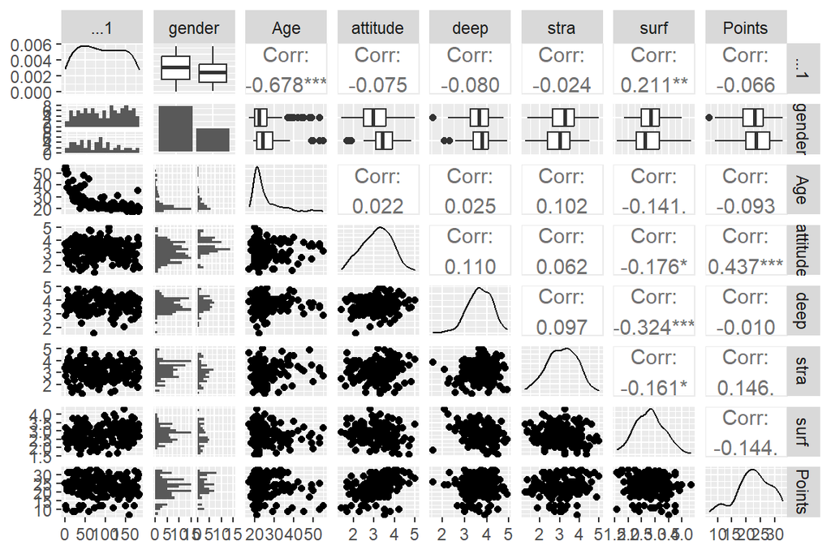

```r
ggpairs(learning2014, mapping = aes(), lower = list(combo = wrap("facethist", bins = 20)))
```

The above graphs give us an idea about the data, for example:

### Linear Regression

We attempt to use multiple linear regression to see what combination of variables has a significant effect on the variable “Points”. Therefore,, “Points” is the target variable in these models.

```r
# We create a regression model with the three learning approaches "stra", "surf" and "deep" as explanatory variables

a <- lm(Points~stra+surf+deep, data = learning2014)

# Summarising the model to help us decide weather the explanatory variables have a significant effect on Points.

summary (a)
```

```
##
## Call:
## lm(formula = Points ~ stra + surf + deep, data = learning2014)
##
## Residuals:
##      Min       1Q   Median       3Q      Max
## -15.1235  -3.0737   0.5226   4.2799  10.3229
##
## Coefficients:
##             Estimate Std. Error t value Pr(>|t|)
## (Intercept)  26.9143     5.1169   5.260  4.5e-07 ***
## stra          0.9878     0.5962   1.657   0.0994 .
## surf         -1.6296     0.9153  -1.780   0.0769 .
## deep         -0.7443     0.8662  -0.859   0.3915
## ---
## Signif. codes:  0 '***' 0.001 '**' 0.01 '*' 0.05 '.' 0.1 ' ' 1
##
## Residual standard error: 5.827 on 162 degrees of freedom
## Multiple R-squared:  0.04071,    Adjusted R-squared:  0.02295
## F-statistic: 2.292 on 3 and 162 DF,  p-value: 0.08016
```

1. *“deep”* does *not* have a *significant* relationship with “Points”
2. The *multiple R-squared* in 0.04, which means the model can only *explain about 4% of the data*.

We will try to replace the insignificant variable with another variable and see if it improves the model a bit. We will call this new model “b”.

```r
# Replacing "deep" with "attitude" as an explanatory variable

b <- lm(Points~stra+surf+attitude, data = learning2014)

# Summarising model "b" to help us decide weather the explanatory variables have a significant effect on Points.

summary (b)
```

```
##
## Call:
## lm(formula = Points ~ stra + surf + attitude, data = learning2014)
##
## Residuals:
##      Min       1Q   Median       3Q      Max
## -17.1550  -3.4346   0.5156   3.6401  10.8952
##
## Coefficients:
##             Estimate Std. Error t value Pr(>|t|)
## (Intercept)  11.0171     3.6837   2.991  0.00322 **
## stra          0.8531     0.5416   1.575  0.11716
## surf         -0.5861     0.8014  -0.731  0.46563
## attitude      3.3952     0.5741   5.913 1.93e-08 ***
## ---
## Signif. codes:  0 '***' 0.001 '**' 0.01 '*' 0.05 '.' 0.1 ' ' 1
##
## Residual standard error: 5.296 on 162 degrees of freedom
## Multiple R-squared:  0.2074, Adjusted R-squared:  0.1927
## F-statistic: 14.13 on 3 and 162 DF,  p-value: 3.156e-08
```

The variable “attitude” has a significant, direct relationship with our target variable. However, “stra” and “surf” do not.

```r
# Replacing variables again
c <- lm(Points~stra+deep+attitude, data = learning2014)

# Summarising model "b" to help us decide weather the explanatory variables have a significant effect on Points.

summary (c)
```

```
##
## Call:
## lm(formula = Points ~ stra + deep + attitude, data = learning2014)
##
## Residuals:
##      Min       1Q   Median       3Q      Max
## -17.5239  -3.4276   0.5474   3.8220  11.5112
##
## Coefficients:
##             Estimate Std. Error t value Pr(>|t|)
## (Intercept)  11.3915     3.4077   3.343  0.00103 **
## stra          0.9621     0.5367   1.793  0.07489 .
## deep         -0.7492     0.7507  -0.998  0.31974
## attitude      3.5254     0.5683   6.203 4.44e-09 ***
## ---
## Signif. codes:  0 '***' 0.001 '**' 0.01 '*' 0.05 '.' 0.1 ' ' 1
##
## Residual standard error: 5.289 on 162 degrees of freedom
## Multiple R-squared:  0.2097, Adjusted R-squared:  0.195
## F-statistic: 14.33 on 3 and 162 DF,  p-value: 2.521e-08
```

```r
# Replacing variables again
d <- lm(Points~stra+Age+attitude, data = learning2014)

# Summarising model "b" to help us decide weather the explanatory variables have a significant effect on Points.

summary (d)
```

```
##
## Call:
## lm(formula = Points ~ stra + Age + attitude, data = learning2014)
##
## Residuals:
##      Min       1Q   Median       3Q      Max
## -18.1149  -3.2003   0.3303   3.4129  10.7599
##
## Coefficients:
##             Estimate Std. Error t value Pr(>|t|)
## (Intercept) 10.89543    2.64834   4.114 6.17e-05 ***
## stra         1.00371    0.53434   1.878   0.0621 .
## Age         -0.08822    0.05302  -1.664   0.0981 .
## attitude     3.48077    0.56220   6.191 4.72e-09 ***
## ---
## Signif. codes:  0 '***' 0.001 '**' 0.01 '*' 0.05 '.' 0.1 ' ' 1
##
## Residual standard error: 5.26 on 162 degrees of freedom
## Multiple R-squared:  0.2182, Adjusted R-squared:  0.2037
## F-statistic: 15.07 on 3 and 162 DF,  p-value: 1.07e-08
```

The next section explains this model

### Explaining the model

Model “d” uses the variables “stra”, “Age” and “Attitude” to explain the variations in the target variable , “Points”.

##### **R-squared**

The multiple R-squared value of **0.2182** denotes that the model can accurately explain **21.82% of variations in points**, using the three explanatory variables.

### Validating the Model

The model’s validity will be tested using diagnostic plots using the plot() function.

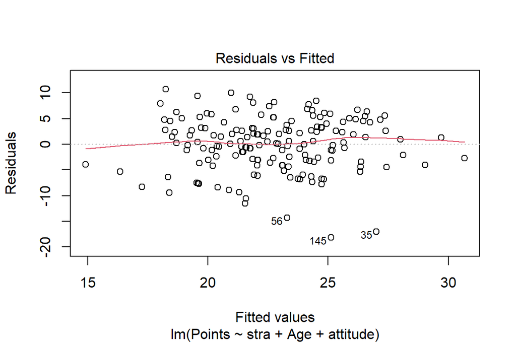

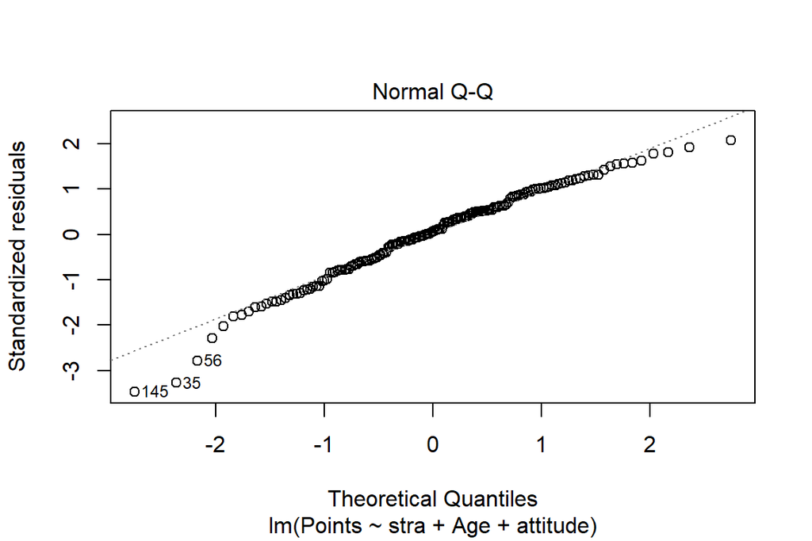

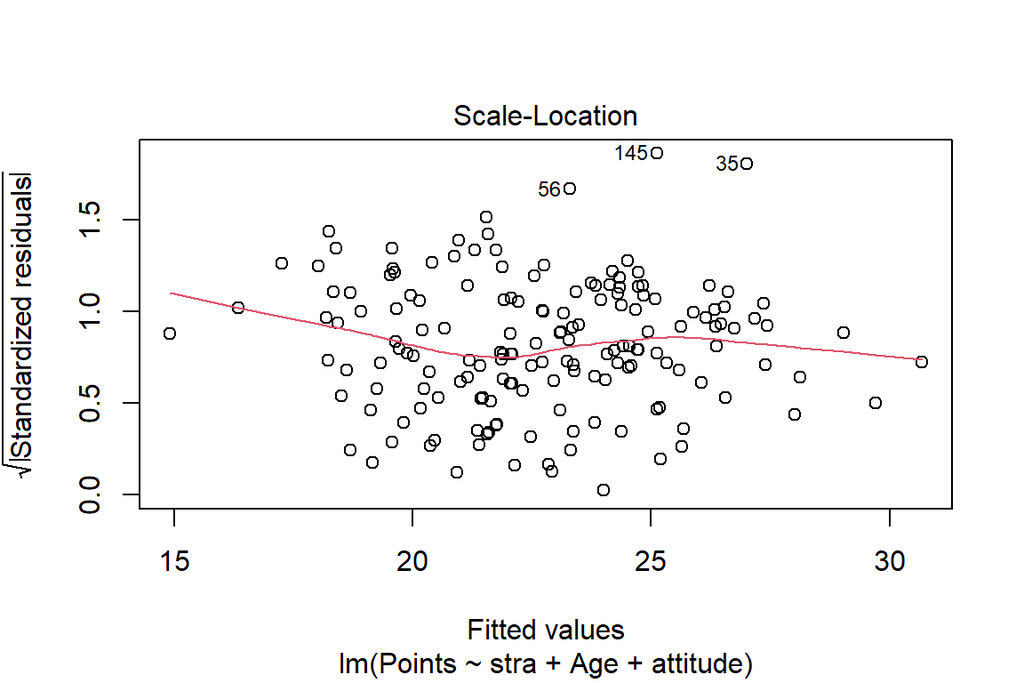

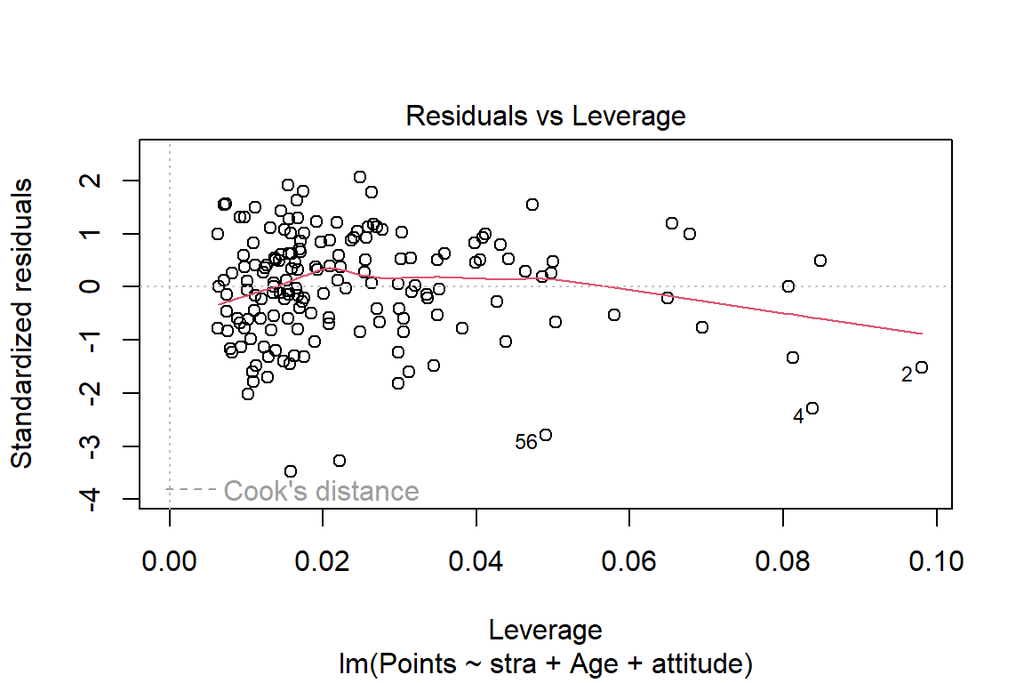

```r
# Producing diagnostic plots for the model "d"
plot(d)
```

##### **Residuals v/s Fitted**

- The residuals are distributed randomly and do not have any obvious patterns (although it also appears that more residuals fall above zero). On the whole, the plot indicates that the values deviate more or less randomly from the values predicted by the model.
  - This suggests that the relationship between the variables is more or less linear.
- There appear to be a few outliers (points 56, 145 and 35).

##### **Normal QQ-plot**

- Not all points coincide with the line, and there appear to be some negative residuals (those falling below the line). This suggests that the data may be skewed and not perfectly normally distributed.

##### **Residuals v/s Leverage**

- The lines indicating Cook’s distance are not visible in our Residuals v/s Leverage Plot. This indicates that all points fall within Cook’s distance. If any points had lied beyond Cook’s distance, they would be the most influential points in our data, removing which could potentially change the interpretation of the model. Therefore, we can assume that model “d” does not have any such points.

# Logistic Regression

Installing packages

```r
options(repos = list(CRAN="http://cran.rstudio.com/"))
install.packages("boot")
install.packages("readr")
install.packages("dplyr")
install.packages("tidyverse")
```

```r
install.packages("ggplot2")
install.packages("GGally")
install.packages("DT")
```

```
##
##   There is a binary version available but the source version is later:
##    binary source needs_compilation
## DT   0.30   0.31             FALSE
```

```
## installing the source package 'DT'
```

```r
library(boot)
library(readr)
library(dplyr)
library(tidyverse)
```

```r
library(ggplot2)
library(GGally)
library(DT)
```

Reading data

```r
alc <- read_csv("data/alc.csv")
```

```
## ──────────────────────────────────────────────────────── Delimiter: "," chr
## (17): school, sex, address, famsize, Pstatus, Mjob, Fjob, reason, guardi... dbl
## (19): ...1, ...2, age, Medu, Fedu, traveltime, studytime, famrel, freeti... lgl
## (1): high_use
```

## About the data and hypotheses

The data studies student performance in secondary education of two Portuguese schools. The data attributes include student grades, demographic, social and school related features, in the context of their performance in two distinct subjects, Mathematics and Portuguese language. In this chapter, we are interested in observing the relationship of alcohol consumption by students with some selected parameters. For this, we formulate the following hypotheses:

- Alcohol consumption varies significantly with **age (age)**, with older students consuming more alcohol than younger students
- Alcohol consumption varies significantly with **engagement in extra-curricular activities (activities)**, with students engaging in extracurricular activities consuming lesser alcohol.
- Alcohol consumption varies significantly with the **quality of family relationship (Famrel)**, with a better quality associated with lower alcohol consumption.
- Alcohol consumption varies significantly with the student’s **frequency of going out with friends (goout)**, higher frequency associated with higher alcohol consumption.

### Numerically and graphically testing hypotheses

We will use cross-tables to numerically explore the data to see if any of our hypotheses are correct.

Installing package

```r
install.packages("crosstable")
library(crosstable)
```

Numerical testing

```r
# age, famrel and goout are currently recognized as numerical variables, and that is messing up the output of this chunk. So, these variables have been converted to factors.
alc$age <- as.factor(alc$age)
alc$famrel <- as.factor(alc$famrel)
alc$goout <- as.factor(alc$goout)
t1 <- crosstable(alc,  c("age", "activities", "famrel", "goout"), by = high_use, total = c("row"), percent_pattern = "{n}({p_col}/{p_row})", percent_digits=0, funs = c(` ` = cross_summary))
as_flextable(t1)
```

| label | variable | high_use FALSE | high_use TRUE | Total |  |
| --- | --- | --- | --- | --- | --- |
| age | 15 | 63(24%/78%) | 18(16%/22%) |  | 81 (22%) |
|  | 16 | 74(29%/73%) | 28(25%/27%) | 102 (28%) |  |
|  | 17 | 62(24%/64%) | 35(32%/36%) | 97 (26%) |  |
|  | 18 | 52(20%/68%) | 25(23%/32%) | 77 (21%) |  |
|  | 19 | 7(3%/64%) | 4(4%/36%) | 11 (3%) |  |
|  | 20 | 1(0.4%/100%) | 0(0%/0%) | 1 (0.3%) |  |
|  | 22 | 0(0%/0%) | 1(1%/100%) | 1 (0.3%) |  |
| activities | no | 120(46%/67%) | 59(53%/33%) | 179 (48%) |  |
|  | yes | 139(54%/73%) | 52(47%/27%) | 191 (52%) |  |
| famrel | 1 | 6(2%/75%) | 2(2%/25%) | 8 (2%) |  |
|  | 2 | 9(3%/50%) | 9(8%/50%) | 18 (5%) |  |
|  | 3 | 39(15%/61%) | 25(23%/39%) | 64 (17%) |  |
|  | 4 | 128(49%/71%) | 52(47%/29%) | 180 (49%) |  |
|  | 5 | 77(30%/77%) | 23(21%/23%) | 100 (27%) |  |
| goout | 1 | 19(7%/86%) | 3(3%/14%) | 22 (6%) |  |
|  | 2 | 82(32%/85%) | 15(14%/15%) | 97 (26%) |  |
|  | 3 | 97(37%/81%) | 23(21%/19%) | 120 (32%) |  |
|  | 4 | 40(15%/51%) | 38(34%/49%) | 78 (21%) |  |
|  | 5 | 21(8%/40%) | 32(29%/60%) | 53 (14%) |  |

Graphical testing:

**1. Alcohol consumption vs Age**

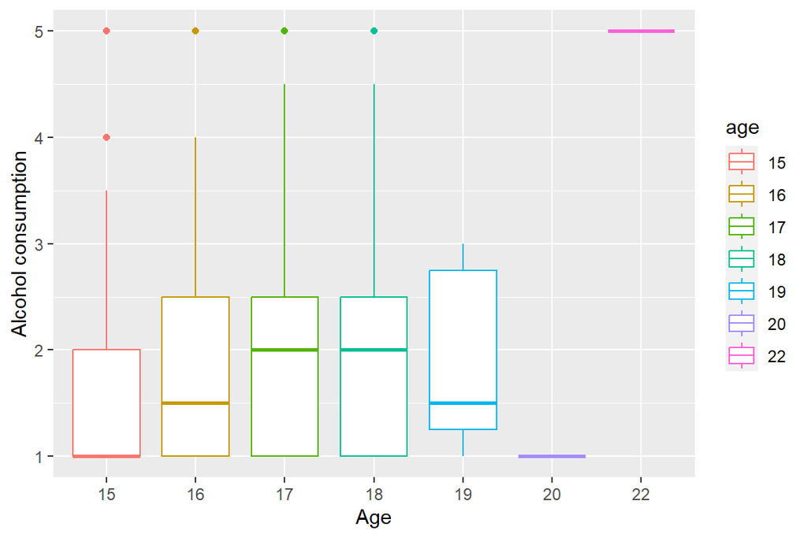

```r
ggplot(alc, aes(age, alc_use)) +geom_boxplot(aes(color = age)) +  xlab("Age") + ylab("Alcohol consumption")
```

Alcohol consumption appears to rise upto the age of 17-18, but there are no obvious trends beyond this point.

**2. Alcohol consumption vs Extracurricular Activities**

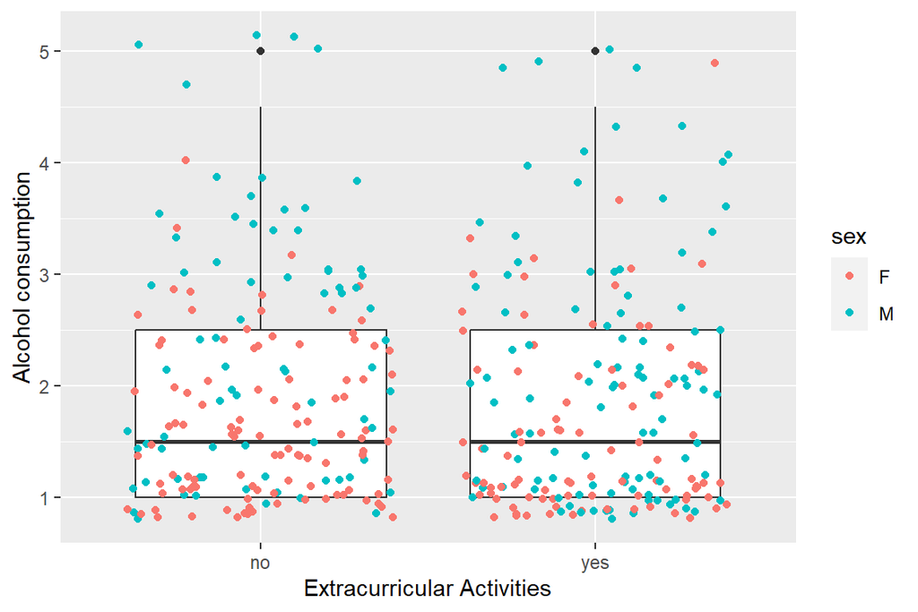

```r
ggplot(alc, aes(activities, alc_use)) +geom_boxplot() + geom_jitter(aes(color = sex)) + xlab("Extracurricular Activities") + ylab("Alcohol consumption")
```

Alcohol consumption appears to be more or less similar regardless of involvement in extra-curricular activities. Our hypothesis does not appear to hold true.

**3. Alcohol consumption vs Quality of family relationship**

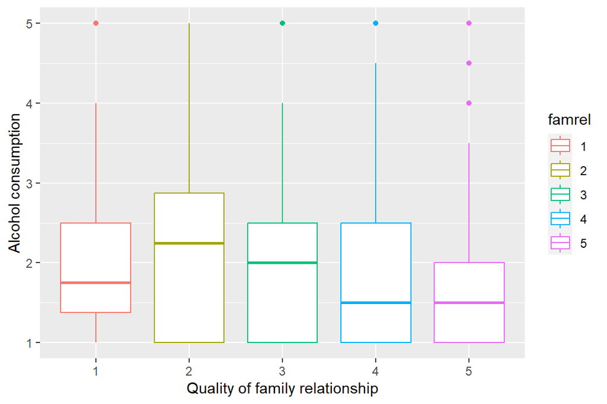

```r
ggplot(alc, aes(famrel, alc_use)) +geom_boxplot(aes(color = famrel)) + xlab("Quality of family relationship") + ylab("Alcohol consumption")
```

An imrproving relationship with one’s family appears to be associated with lower alcohol consumption in general.

**4. Alcohol consumption vs frequency of going out**

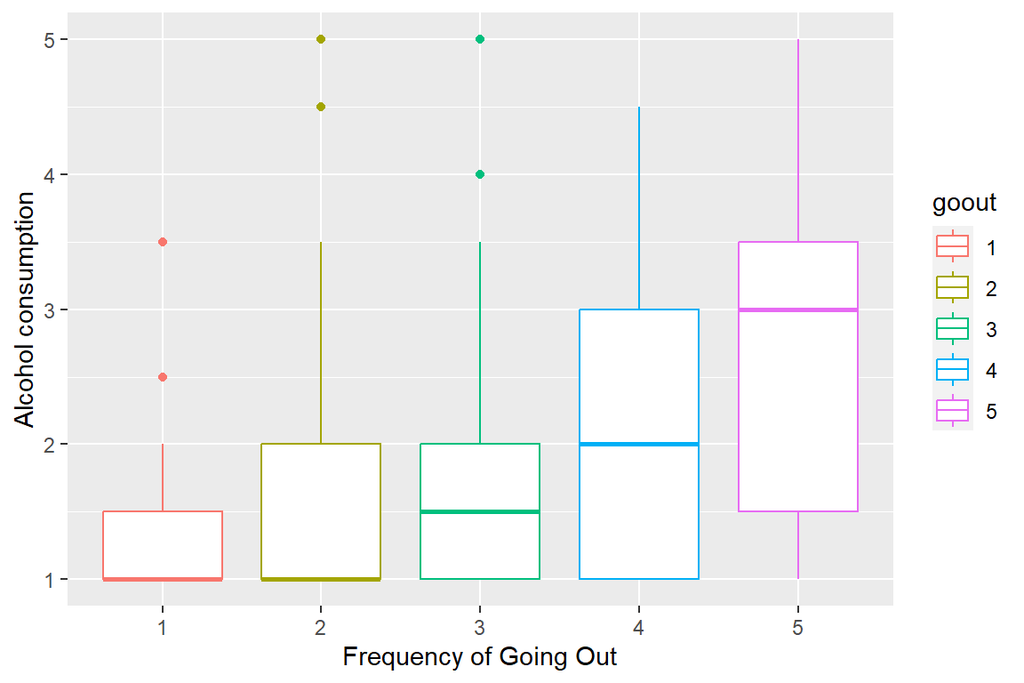

```r
ggplot(alc, aes(goout, alc_use)) +geom_boxplot(aes(color = goout)) + xlab("Frequency of Going Out") + ylab("Alcohol consumption")
```

The frequency of going out appears to have a direct relationship with alcohol consumption. Our hypothesis appears to be correct.

## Model:

**Generalized Linear Models** allow us to perform linear regressions for data that are not normally distributed. Since there are categorical variables, we cannot run linear regressions with normal distributions. We will therefore use the glm function with a **binomial distribution**.

```r
# Converting factors back to numeric for modeling
alc$age <- as.numeric(alc$age)
alc$famrel <- as.numeric(alc$famrel)
alc$goout <- as.numeric(alc$goout)
m <- glm(high_use ~ age + activities + famrel + goout, data = alc, family = "binomial")
summary(m)
```

```
##
## Call:
## glm(formula = high_use ~ age + activities + famrel + goout, family = "binomial",
##     data = alc)
##
## Deviance Residuals:
##     Min       1Q   Median       3Q      Max
## -1.5177  -0.8037  -0.5508   0.9968   2.4836
##
## Coefficients:
##               Estimate Std. Error z value Pr(>|z|)
## (Intercept)    -2.0469     0.6613  -3.095  0.00197 **
## age             0.1101     0.1087   1.013  0.31123
## activitiesyes  -0.3312     0.2491  -1.330  0.18360
## famrel         -0.3890     0.1358  -2.864  0.00419 **
## goout           0.7869     0.1208   6.514 7.33e-11 ***
## ---
## Signif. codes:  0 '***' 0.001 '**' 0.01 '*' 0.05 '.' 0.1 ' ' 1
##
## (Dispersion parameter for binomial family taken to be 1)
##
##     Null deviance: 452.04  on 369  degrees of freedom
## Residual deviance: 391.67  on 365  degrees of freedom
## AIC: 401.67
##
## Number of Fisher Scoring iterations: 4
```

```r
OR <- coef(m) %>% exp
CI <- confint(m)
cbind(OR, CI)
```

```
##                      OR      2.5 %     97.5 %
## (Intercept)   0.1291398 -3.3730441 -0.7716864
## age           1.1163679 -0.1029974  0.3243667
## activitiesyes 0.7180718 -0.8226507  0.1555969
## famrel        0.6777087 -0.6587038 -0.1241970
## goout         2.1965650  0.5565977  1.0312327
```

### Model Interpretation:

Of the four variables, only two have a **significant (p<0.01)** influence on whether or not the alcohol consumption by a student is high:

1. The quality of their relationship with their family, and
2. Their frequency of going out.

## Predictive Power:

```r
# Adding a column that displays the output for whether alcohol consumption is high or not, based on the model
## We first add a column that computes the probability for high alcohol consumption using our model

alc <- mutate(alc, probability = predict(m, type = "response"))

## If the probability is greater than 50% (or 0.5), the model will predict high alcohol consumption to be "True", and otherwise, "False". These outputs will be displayed in another column.  We call this column "prediction"

alc <- mutate(alc, prediction = probability > 0.5)




# Tabulating the target variable versus the predictions
table(high_use = alc$high_use, prediction = alc$prediction)
```

```
##         prediction
## high_use FALSE TRUE
##    FALSE   235   24
##    TRUE     71   40
```

[figure not shown]

```r
# Plotting the predictive power
g <- ggplot(alc, aes(x = "probability", y = "high use")) + geom_point()

g
```

From the table, it appears that the present model can fairly reliably predict when alcohol consumption is not high, but it can predict conditions of high alcohol consumption to be false as well. We will attempt to estimate the average number of wrongly classified students in the next steps:

```r
# define a loss function (mean prediction error)
loss_func <- function(class, prob) {
  n_wrong <- abs(class - prob) > 0.5
  mean(n_wrong)
}

loss_func(class = alc$high_use, prob = 0)
```

```
## [1] 0.3
```

# Chapter 4: Clustering and Classification

Packages:

```r
options(repos = list(CRAN="http://cran.rstudio.com/"))

library(MASS)
```

```r
library(corrplot)
library(readr)
library(dplyr)
library(tidyverse)
library(ggplot2)
library(GGally)
library(DT)
```

Data

```r
data("Boston")
str(Boston)
```

```
## 'data.frame':    506 obs. of  14 variables:
##  $ crim   : num  0.00632 0.02731 0.02729 0.03237 0.06905 ...
##  $ zn     : num  18 0 0 0 0 0 12.5 12.5 12.5 12.5 ...
##  $ indus  : num  2.31 7.07 7.07 2.18 2.18 2.18 7.87 7.87 7.87 7.87 ...
##  $ chas   : int  0 0 0 0 0 0 0 0 0 0 ...
##  $ nox    : num  0.538 0.469 0.469 0.458 0.458 0.458 0.524 0.524 0.524 0.524 ...
##  $ rm     : num  6.58 6.42 7.18 7 7.15 ...
##  $ age    : num  65.2 78.9 61.1 45.8 54.2 58.7 66.6 96.1 100 85.9 ...
##  $ dis    : num  4.09 4.97 4.97 6.06 6.06 ...
##  $ rad    : int  1 2 2 3 3 3 5 5 5 5 ...
##  $ tax    : num  296 242 242 222 222 222 311 311 311 311 ...
##  $ ptratio: num  15.3 17.8 17.8 18.7 18.7 18.7 15.2 15.2 15.2 15.2 ...
##  $ black  : num  397 397 393 395 397 ...
##  $ lstat  : num  4.98 9.14 4.03 2.94 5.33 ...
##  $ medv   : num  24 21.6 34.7 33.4 36.2 28.7 22.9 27.1 16.5 18.9 ...
```

```r
dim(Boston)
```

```
## [1] 506  14
```

Graphical Overview:

[figure not shown]

```r
ggpairs(Boston)
```

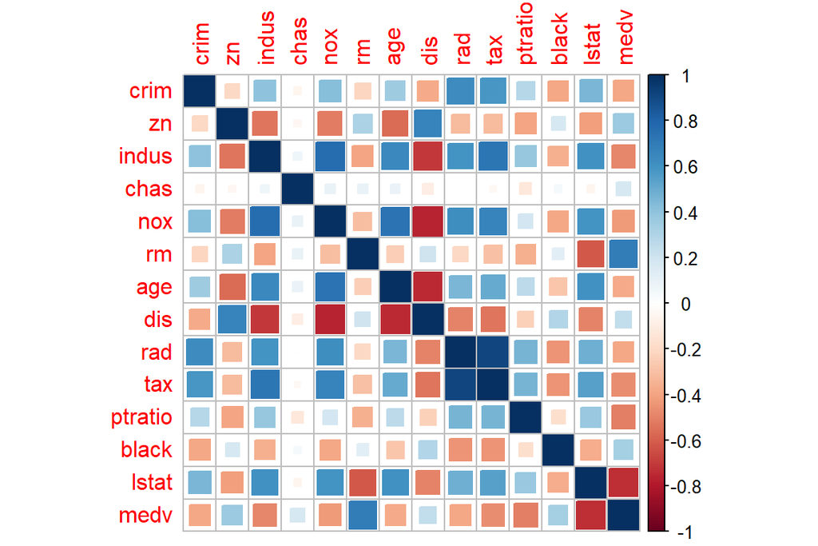

```r
# the output is too cluttered and confusing

cor_matrix <- cor(Boston)
corrplot(cor_matrix, method = "square")
```

Summary of relationships:

```r
cor_matrix
```

```
##                crim          zn       indus         chas         nox
## crim     1.00000000 -0.20046922  0.40658341 -0.055891582  0.42097171
## zn      -0.20046922  1.00000000 -0.53382819 -0.042696719 -0.51660371
## indus    0.40658341 -0.53382819  1.00000000  0.062938027  0.76365145
## chas    -0.05589158 -0.04269672  0.06293803  1.000000000  0.09120281
## nox      0.42097171 -0.51660371  0.76365145  0.091202807  1.00000000
## rm      -0.21924670  0.31199059 -0.39167585  0.091251225 -0.30218819
## age      0.35273425 -0.56953734  0.64477851  0.086517774  0.73147010
## dis     -0.37967009  0.66440822 -0.70802699 -0.099175780 -0.76923011
## rad      0.62550515 -0.31194783  0.59512927 -0.007368241  0.61144056
## tax      0.58276431 -0.31456332  0.72076018 -0.035586518  0.66802320
## ptratio  0.28994558 -0.39167855  0.38324756 -0.121515174  0.18893268
## black   -0.38506394  0.17552032 -0.35697654  0.048788485 -0.38005064
## lstat    0.45562148 -0.41299457  0.60379972 -0.053929298  0.59087892
## medv    -0.38830461  0.36044534 -0.48372516  0.175260177 -0.42732077
##                  rm         age         dis          rad         tax    ptratio
## crim    -0.21924670  0.35273425 -0.37967009  0.625505145  0.58276431  0.2899456
## zn       0.31199059 -0.56953734  0.66440822 -0.311947826 -0.31456332 -0.3916785
## indus   -0.39167585  0.64477851 -0.70802699  0.595129275  0.72076018  0.3832476
## chas     0.09125123  0.08651777 -0.09917578 -0.007368241 -0.03558652 -0.1215152
## nox     -0.30218819  0.73147010 -0.76923011  0.611440563  0.66802320  0.1889327
## rm       1.00000000 -0.24026493  0.20524621 -0.209846668 -0.29204783 -0.3555015
## age     -0.24026493  1.00000000 -0.74788054  0.456022452  0.50645559  0.2615150
## dis      0.20524621 -0.74788054  1.00000000 -0.494587930 -0.53443158 -0.2324705
## rad     -0.20984667  0.45602245 -0.49458793  1.000000000  0.91022819  0.4647412
## tax     -0.29204783  0.50645559 -0.53443158  0.910228189  1.00000000  0.4608530
## ptratio -0.35550149  0.26151501 -0.23247054  0.464741179  0.46085304  1.0000000
## black    0.12806864 -0.27353398  0.29151167 -0.444412816 -0.44180801 -0.1773833
## lstat   -0.61380827  0.60233853 -0.49699583  0.488676335  0.54399341  0.3740443
## medv     0.69535995 -0.37695457  0.24992873 -0.381626231 -0.46853593 -0.5077867
##               black      lstat       medv
## crim    -0.38506394  0.4556215 -0.3883046
## zn       0.17552032 -0.4129946  0.3604453
## indus   -0.35697654  0.6037997 -0.4837252
## chas     0.04878848 -0.0539293  0.1752602
## nox     -0.38005064  0.5908789 -0.4273208
## rm       0.12806864 -0.6138083  0.6953599
## age     -0.27353398  0.6023385 -0.3769546
## dis      0.29151167 -0.4969958  0.2499287
## rad     -0.44441282  0.4886763 -0.3816262
## tax     -0.44180801  0.5439934 -0.4685359
## ptratio -0.17738330  0.3740443 -0.5077867
## black    1.00000000 -0.3660869  0.3334608
## lstat   -0.36608690  1.0000000 -0.7376627
## medv     0.33346082 -0.7376627  1.0000000
```

## Relationships between variables:

We will start with the per capita crime rate (crime) as it is the parameter we will be observing in this exercise

## Scaling the dataset

Scaling the entire datast as all variables have numerical values

```r
boston_scaled <- scale(Boston)
summary(boston_scaled)
```

```
##       crim                 zn               indus              chas
##  Min.   :-0.419367   Min.   :-0.48724   Min.   :-1.5563   Min.   :-0.2723
##  1st Qu.:-0.410563   1st Qu.:-0.48724   1st Qu.:-0.8668   1st Qu.:-0.2723
##  Median :-0.390280   Median :-0.48724   Median :-0.2109   Median :-0.2723
##  Mean   : 0.000000   Mean   : 0.00000   Mean   : 0.0000   Mean   : 0.0000
##  3rd Qu.: 0.007389   3rd Qu.: 0.04872   3rd Qu.: 1.0150   3rd Qu.:-0.2723
##  Max.   : 9.924110   Max.   : 3.80047   Max.   : 2.4202   Max.   : 3.6648
##       nox                rm               age               dis
##  Min.   :-1.4644   Min.   :-3.8764   Min.   :-2.3331   Min.   :-1.2658
##  1st Qu.:-0.9121   1st Qu.:-0.5681   1st Qu.:-0.8366   1st Qu.:-0.8049
##  Median :-0.1441   Median :-0.1084   Median : 0.3171   Median :-0.2790
##  Mean   : 0.0000   Mean   : 0.0000   Mean   : 0.0000   Mean   : 0.0000
##  3rd Qu.: 0.5981   3rd Qu.: 0.4823   3rd Qu.: 0.9059   3rd Qu.: 0.6617
##  Max.   : 2.7296   Max.   : 3.5515   Max.   : 1.1164   Max.   : 3.9566
##       rad               tax             ptratio            black
##  Min.   :-0.9819   Min.   :-1.3127   Min.   :-2.7047   Min.   :-3.9033
##  1st Qu.:-0.6373   1st Qu.:-0.7668   1st Qu.:-0.4876   1st Qu.: 0.2049
##  Median :-0.5225   Median :-0.4642   Median : 0.2746   Median : 0.3808
##  Mean   : 0.0000   Mean   : 0.0000   Mean   : 0.0000   Mean   : 0.0000
##  3rd Qu.: 1.6596   3rd Qu.: 1.5294   3rd Qu.: 0.8058   3rd Qu.: 0.4332
##  Max.   : 1.6596   Max.   : 1.7964   Max.   : 1.6372   Max.   : 0.4406
##      lstat              medv
##  Min.   :-1.5296   Min.   :-1.9063
##  1st Qu.:-0.7986   1st Qu.:-0.5989
##  Median :-0.1811   Median :-0.1449
##  Mean   : 0.0000   Mean   : 0.0000
##  3rd Qu.: 0.6024   3rd Qu.: 0.2683
##  Max.   : 3.5453   Max.   : 2.9865
```

```r
# converting the scaled dataset to a dataframe for analyses

boston_scaled <- as.data.frame(boston_scaled)
```

```r
summary(Boston)
```

```
##       crim                zn             indus            chas
##  Min.   : 0.00632   Min.   :  0.00   Min.   : 0.46   Min.   :0.00000
##  1st Qu.: 0.08205   1st Qu.:  0.00   1st Qu.: 5.19   1st Qu.:0.00000
##  Median : 0.25651   Median :  0.00   Median : 9.69   Median :0.00000
##  Mean   : 3.61352   Mean   : 11.36   Mean   :11.14   Mean   :0.06917
##  3rd Qu.: 3.67708   3rd Qu.: 12.50   3rd Qu.:18.10   3rd Qu.:0.00000
##  Max.   :88.97620   Max.   :100.00   Max.   :27.74   Max.   :1.00000
##       nox               rm             age              dis
##  Min.   :0.3850   Min.   :3.561   Min.   :  2.90   Min.   : 1.130
##  1st Qu.:0.4490   1st Qu.:5.886   1st Qu.: 45.02   1st Qu.: 2.100
##  Median :0.5380   Median :6.208   Median : 77.50   Median : 3.207
##  Mean   :0.5547   Mean   :6.285   Mean   : 68.57   Mean   : 3.795
##  3rd Qu.:0.6240   3rd Qu.:6.623   3rd Qu.: 94.08   3rd Qu.: 5.188
##  Max.   :0.8710   Max.   :8.780   Max.   :100.00   Max.   :12.127
##       rad              tax           ptratio          black
##  Min.   : 1.000   Min.   :187.0   Min.   :12.60   Min.   :  0.32
##  1st Qu.: 4.000   1st Qu.:279.0   1st Qu.:17.40   1st Qu.:375.38
##  Median : 5.000   Median :330.0   Median :19.05   Median :391.44
##  Mean   : 9.549   Mean   :408.2   Mean   :18.46   Mean   :356.67
##  3rd Qu.:24.000   3rd Qu.:666.0   3rd Qu.:20.20   3rd Qu.:396.23
##  Max.   :24.000   Max.   :711.0   Max.   :22.00   Max.   :396.90
##      lstat            medv
##  Min.   : 1.73   Min.   : 5.00
##  1st Qu.: 6.95   1st Qu.:17.02
##  Median :11.36   Median :21.20
##  Mean   :12.65   Mean   :22.53
##  3rd Qu.:16.95   3rd Qu.:25.00
##  Max.   :37.97   Max.   :50.00
```

We can see that integers have been converted to decimal values now. Hence we now have a dataset with all continuous variables, with both positive and negative values.The variables in the new dataset have been standardized so thet the mean value for each variable is 0.

Now, we will start to look at the relationships of the per capita crime rate with other variables.

Converting the new scaled crime rate (crim) to factor with the quantiles as intervals. We will label this variable “crime”:

```r
boston_scaled$crim <- as.numeric(boston_scaled$crim)

bins <- quantile(boston_scaled$crim)


boston_scaled$crime <- cut(boston_scaled$crim, breaks = bins, include.lowest = TRUE, labels = c("low", "med_low", "med_high", "high"))

boston_scaled <- dplyr::select(boston_scaled, -crim)
```

The new variable “crime” has been divided into four levels:

- -0.419 to -0.411 (low)
- -0.411 to -0.39 (med_low)
- -0.39 to 0.00739 (med_high)
- 0.00739 to 9.92 (high)

## Clustering and analysis:

Creating the train and test datasets to check the performance of our models:

```r
nrow(Boston)
```

```
## [1] 506
```

```r
# to keep 80% (0.8) of the rows in the train dataset, we need to multiply the total number of rows in the complete dataset by 0.8

n <- nrow(boston_scaled)

# choose randomly 80% of the rows
ind <- sample(n,  size = n * 0.8)

# create train set
train <- boston_scaled[ind,]

# create test set
test <- boston_scaled[-ind,]

test$correct_classes <- test$crime

test <- dplyr::select(test, -crime)

dim(train)
```

```
## [1] 404  14
```

```r
dim(test)
```

```
## [1] 102  14
```

## Linear Discriminant Analysis:

```r
lda.fit_train <- lda(crime ~ ., data = train)
lda.fit_train
```

```
## Call:
## lda(crime ~ ., data = train)
##
## Prior probabilities of groups:
##       low   med_low  med_high      high
## 0.2425743 0.2524752 0.2698020 0.2351485
##
## Group means:
##                   zn      indus        chas        nox         rm        age
## low       1.03883585 -0.9236960 -0.15180559 -0.8913706  0.4841350 -0.9542708
## med_low  -0.06288265 -0.2673524 -0.07933396 -0.5652424 -0.1277256 -0.3708366
## med_high -0.38417771  0.1409256  0.23335353  0.3736334  0.1400119  0.4762152
## high     -0.48724019  1.0172655 -0.06511327  1.0492888 -0.5237601  0.7962122
##                 dis        rad        tax     ptratio       black        lstat
## low       0.8795415 -0.6842073 -0.7378767 -0.50028262  0.37518539 -0.804888336
## med_low   0.3563841 -0.5483812 -0.4532189 -0.03787817  0.30793872 -0.153836154
## med_high -0.3817255 -0.4139595 -0.3310108 -0.29050527  0.08351511 -0.005310923
## high     -0.8608770  1.6366336  1.5129868  0.77903654 -0.75007770  0.887806962
##                  medv
## low       0.586680878
## med_low   0.007519156
## med_high  0.188256417
## high     -0.627676524
##
## Coefficients of linear discriminants:
##                 LD1          LD2          LD3
## zn       0.12201620  0.714782878 -0.942761828
## indus   -0.02256149 -0.164210844  0.387188623
## chas    -0.07058357 -0.136491326  0.002868865
## nox      0.40763976 -0.691787664 -1.230120247
## rm      -0.15983453 -0.131894743 -0.192985069
## age      0.24669036 -0.503644054 -0.202457177
## dis     -0.10643526 -0.330899887  0.264080594
## rad      3.17643945  0.767723328 -0.195281001
## tax     -0.02667124  0.157430752  0.580371643
## ptratio  0.13133611  0.004330888 -0.214446850
## black   -0.15476260  0.009337364  0.091522821
## lstat    0.19943494 -0.104858070  0.406595399
## medv     0.19848608 -0.214132828 -0.037925117
##
## Proportion of trace:
##    LD1    LD2    LD3
## 0.9419 0.0446 0.0135
```

### Comparing with the test set

```r
test <- boston_scaled[-ind,]
test$correct_classes <- test$crime
test <- dplyr::select(test, -crime)
correct_classes <- test$correct_classes

lda.pred <- predict(lda.fit_train, newdata = test)

a <- table(correct = correct_classes, predicted = lda.pred$class)
a
```

```
##           predicted
## correct    low med_low med_high high
##   low       12      15        2    0
##   med_low    3      15        6    0
##   med_high   0       6       10    1
##   high       0       0        0   32
```

```r
diag(a) / rowSums(a)
```

```
##       low   med_low  med_high      high
## 0.4137931 0.6250000 0.5882353 1.0000000
```

### K-means clustering

We will be using the scaled dataset for this.

```r
boston_scaled$crime_rate <- scale(Boston$crim)
km <- kmeans(boston_scaled[,-14], centers = 4)

# Had to remove the column "crime" from this command

km
```

```
## K-means clustering with 4 clusters of sizes 161, 134, 84, 127
##
## Cluster means:
##            zn      indus        chas        nox          rm        age
## 1 -0.03037231 -0.6904932 -0.24787503 -0.7503632 -0.01012308 -0.7218409
## 2 -0.48724019  1.0359674 -0.03727831  1.0077445 -0.38990692  0.7586435
## 3  1.53895973 -1.0038867  0.10263286 -0.7587625  1.32898889 -0.8157700
## 4 -0.46529520  0.4462697  0.28568514  0.3898170 -0.45478523  0.6541956
##          dis        rad        tax     ptratio       black      lstat
## 1  0.6957586 -0.5752711 -0.6948055 -0.06782524  0.36229824 -0.5086872
## 2 -0.8253047  1.6253203  1.5333981  0.80508902 -0.74419107  0.8500550
## 3  0.7305092 -0.6099866 -0.6679270 -1.18096462  0.35004334 -1.0185516
## 4 -0.4944023 -0.5821685 -0.2953212  0.01762963  0.09439328  0.4216504
##         medv crime_rate
## 1  0.1216412 -0.4026024
```

[output cut: 66 more lines]

### Visualizing the clusters

```r
install.packages("ggpubr")
library(ggpubr)
install.packages("factoextra")
library(factoextra)
```

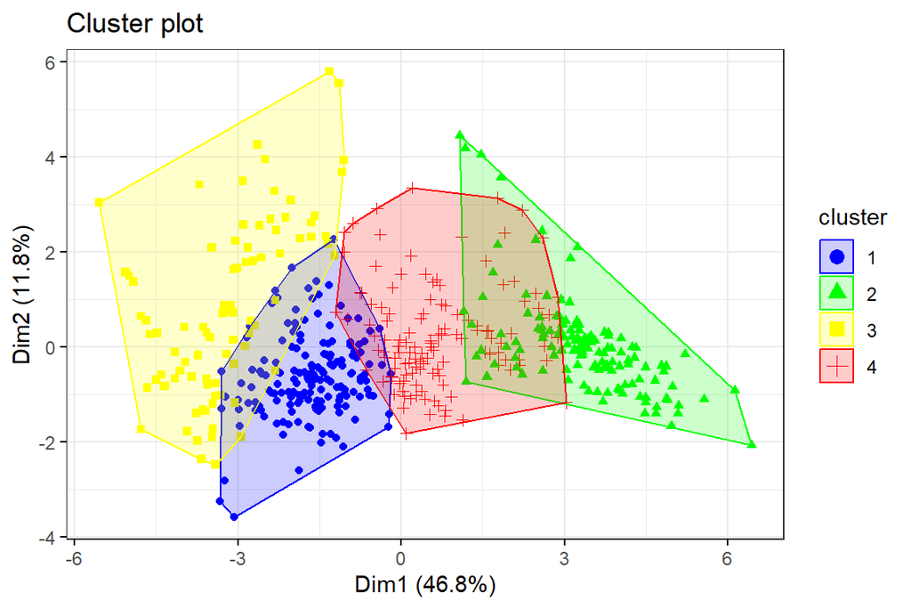

```r
fviz_cluster(km, data = boston_scaled[, -14],
             palette = c("blue", "green", "yellow", "red"),
             geom = "point",
             ellipse.type = "convex",
             ggtheme = theme_bw()
             )
```

```r
# This plot reduces the dimensions to give us a pretty clear representation of how the clusters look.
```

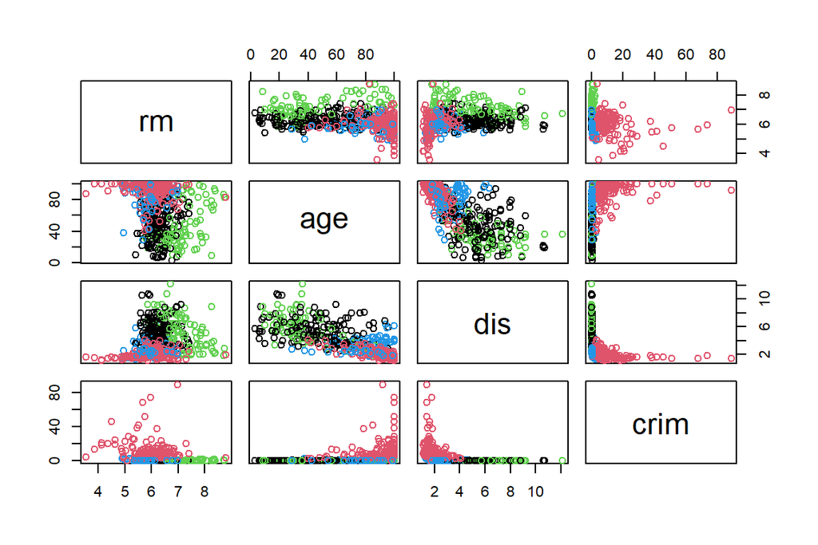

```r
pairs(Boston[c("rm", "age", "dis", "crim")], col = km$cluster)
```

There is still quite an overlap among clusters. Let’s see if changing the number of clusters can change this.

```r
boston_scaled$crime_rate <- scale(Boston$crim)
km2 <- kmeans(boston_scaled[,-14], centers = 6)

# Had to remove the column "crime" from this command

km2
```

```
## K-means clustering with 6 clusters of sizes 58, 50, 96, 149, 38, 115
##
## Cluster means:
##           zn      indus        chas        nox          rm        age
## 1  2.4369066 -1.1954828 -0.20444803 -1.1971770  0.72436579 -1.4369689
## 2 -0.1159242 -0.5447210  0.98754301 -0.1002700  1.68026873  0.2673323
## 3 -0.4872402  1.0881808 -0.06727176  1.0047659 -0.50102709  0.7525132
## 4 -0.1026409 -0.6512569 -0.24590558 -0.7214773 -0.06702194 -0.7386331
## 5 -0.4872402  1.0149946 -0.27232907  0.9805230 -0.29866182  0.7720736
## 6 -0.4779191  0.4397929  0.13849878  0.4194129 -0.49210986  0.6822073
##          dis        rad        tax     ptratio       black      lstat
## 1  1.6523939 -0.6769334 -0.5371532 -0.84752430  0.35232676 -0.9739151
## 2 -0.4054816 -0.3525113 -0.6048350 -1.00858593  0.31359232 -0.9642633
## 3 -0.7982585  1.5399709  1.5433194  0.80337267  0.16543726  0.7715151
## 4  0.6084990 -0.5756684 -0.7160447 -0.10811223  0.36742507 -0.4666616
```

[output cut: 72 more lines]

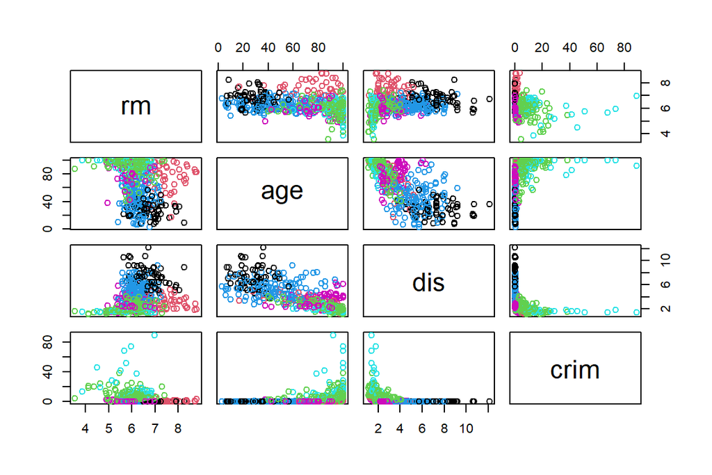

```r
pairs(Boston[c("rm", "age", "dis", "crim")], col = km2$cluster)
```

Let’s try with fewer clusters now.

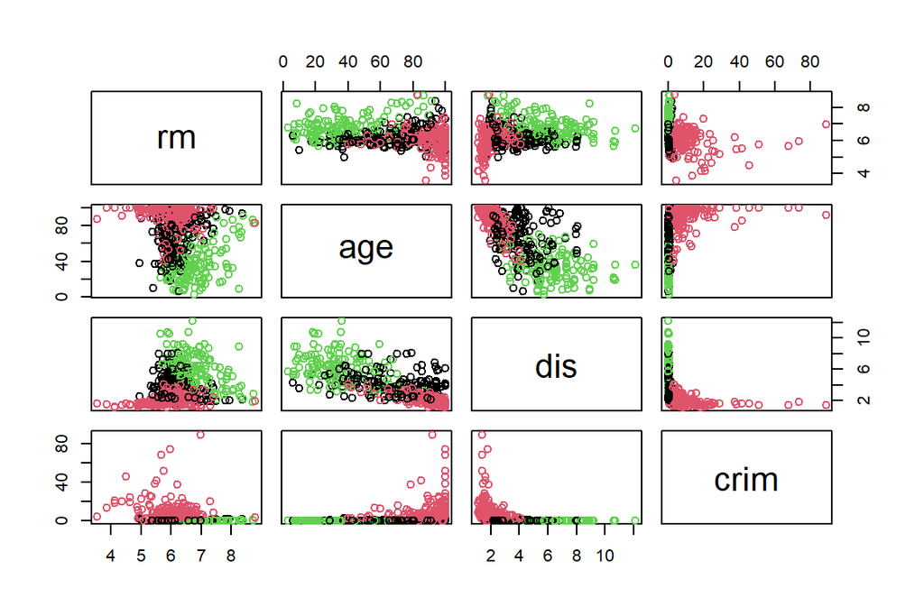

```r
boston_scaled$crime_rate <- scale(Boston$crim)
km3 <- kmeans(boston_scaled[,-14], centers = 3)
pairs(Boston[c("rm", "age", "dis", "crim")], col = km3$cluster)
```

```r
km3
```

```
## K-means clustering with 3 clusters of sizes 216, 152, 138
##
## Cluster means:
##           zn      indus        chas        nox         rm        age
## 1 -0.3935457 -0.1369208  0.07398993 -0.1662087 -0.1700456  0.1673019
## 2 -0.4872402  1.0913679 -0.01330932  1.1109351 -0.4609873  0.7828949
## 3  1.1526549 -0.9877755 -0.10115080 -0.9634859  0.7739125 -1.1241828
##           dis        rad        tax     ptratio      black       lstat
## 1 -0.07766431 -0.5799077 -0.5409630 -0.04596655  0.2680397 -0.05818052
## 2 -0.84882600  1.3656860  1.3895093  0.63256391 -0.7083974  0.90799414
## 3  1.05650031 -0.5965522 -0.6837494 -0.62478941  0.3607235 -0.90904433
##          medv crime_rate
## 1 -0.04811607 -0.3688324
## 2 -0.69550394  0.8942488
## 3  0.84137443 -0.4076669
```

[output cut: 63 more lines]

Let’s try another method to determine the optimal number of clusters:

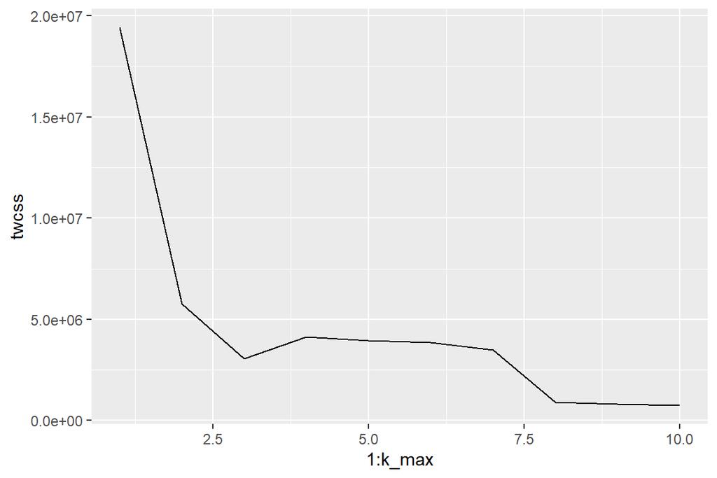

```r
set.seed(123)
k_max <- 10

# calculate the total within sum of squares
twcss <- sapply(1:k_max, function(k){kmeans(Boston, k)$tot.withinss})

qplot(x = 1:k_max, y = twcss, geom = 'line')
```

[figure not shown]

```r
# k-means clustering
km <- kmeans(Boston, centers = k_max)

# plot the Boston dataset with clusters
pairs(Boston, col = km$cluster)
```

It does appear that the within-cluster variability changes considerably when we change the number of clusters from 1 to 2 and 3. However, the lowest value is obtained at around 8-9.

### Bonus exercises:

# Dimensionality Reduction

Packages:

```r
options(repos = list(CRAN="http://cran.rstudio.com/"))

library(MASS)
library(corrplot)
library(readr)
library(dplyr)
library(tidyverse)
library(ggplot2)
library(GGally)
library(DT)
library(tibble)
library(factoextra)
library(FactoMineR)
```

Reading data:

```r
human2 <- read.csv("human2")
DT::datatable(human2, options = list(pageLength = 10))
```

|  | X | country | Edu2FM | Labo.FM | Edu.Exp | Life.exp | GNI | MMR | Ado.Birth | Parli.rep |
| --- | --- | --- | --- | --- | --- | --- | --- | --- | --- | --- |
| 1 | 1 | Norway | 1.00723888314374 | 0.890829694323144 | 17.5 | 81.6 | 64992 | 4 | 7.8 | 39.6 |
| 2 | 2 | Australia | 0.996828752642706 | 0.818941504178273 | 20.2 | 82.4 | 42261 | 6 | 12.1 | 30.5 |
| 3 | 3 | Switzerland | 0.98343685300207 | 0.825100133511348 | 15.8 | 83 | 56431 | 6 | 1.9 | 28.5 |
| 4 | 4 | Denmark | 0.988612836438924 | 0.884036144578313 | 18.7 | 80.2 | 44025 | 5 | 5.1 | 38 |
| 5 | 5 | Netherlands | 0.969060773480663 | 0.828611898016997 | 17.9 | 81.6 | 45435 | 6 | 6.2 | 36.9 |
| 6 | 6 | Germany | 0.992783505154639 | 0.807228915662651 | 16.5 | 80.9 | 43919 | 7 | 3.8 | 36.9 |
| 7 | 7 | Ireland | 1.02417302798982 | 0.779735682819383 | 18.6 | 80.9 | 39568 | 9 | 8.2 | 19.9 |
| 8 | 8 | United States | 1.00316455696203 | 0.817126269956459 | 16.5 | 79.1 | 52947 | 28 | 31 | 19.4 |
| 9 | 9 | Canada | 1 | 0.867605633802817 | 15.9 | 82 | 42155 | 11 | 14.5 | 28.2 |
| 10 | 10 | New Zealand | 0.99685204616999 | 0.840108401084011 | 19.2 | 81.8 | 32689 | 8 | 25.3 | 31.4 |

[output cut: 145 more lines]

Setting country names as row names:

```r
human_ <- column_to_rownames(human2, "country")
datatable(human_, options = list(pageLength = 10))
```

|  | X | Edu2FM | Labo.FM | Edu.Exp | Life.exp | GNI | MMR | Ado.Birth | Parli.rep |
| --- | --- | --- | --- | --- | --- | --- | --- | --- | --- |
| Norway | 1 | 1.00723888314374 | 0.890829694323144 | 17.5 | 81.6 | 64992 | 4 | 7.8 | 39.6 |
| Australia | 2 | 0.996828752642706 | 0.818941504178273 | 20.2 | 82.4 | 42261 | 6 | 12.1 | 30.5 |
| Switzerland | 3 | 0.98343685300207 | 0.825100133511348 | 15.8 | 83 | 56431 | 6 | 1.9 | 28.5 |
| Denmark | 4 | 0.988612836438924 | 0.884036144578313 | 18.7 | 80.2 | 44025 | 5 | 5.1 | 38 |
| Netherlands | 5 | 0.969060773480663 | 0.828611898016997 | 17.9 | 81.6 | 45435 | 6 | 6.2 | 36.9 |
| Germany | 6 | 0.992783505154639 | 0.807228915662651 | 16.5 | 80.9 | 43919 | 7 | 3.8 | 36.9 |
| Ireland | 7 | 1.02417302798982 | 0.779735682819383 | 18.6 | 80.9 | 39568 | 9 | 8.2 | 19.9 |
| United States | 8 | 1.00316455696203 | 0.817126269956459 | 16.5 | 79.1 | 52947 | 28 | 31 | 19.4 |
| Canada | 9 | 1 | 0.867605633802817 | 15.9 | 82 | 42155 | 11 | 14.5 | 28.2 |
| New Zealand | 10 | 0.99685204616999 | 0.840108401084011 | 19.2 | 81.8 | 32689 | 8 | 25.3 | 31.4 |

[output cut: 145 more lines]

```r
summary(human_)
```

```
##        X             Edu2FM          Labo.FM          Edu.Exp
##  Min.   :  1.0   Min.   :0.1717   Min.   :0.1857   Min.   : 5.40
##  1st Qu.: 39.5   1st Qu.:0.7264   1st Qu.:0.5984   1st Qu.:11.25
##  Median : 78.0   Median :0.9375   Median :0.7535   Median :13.50
##  Mean   : 78.0   Mean   :0.8529   Mean   :0.7074   Mean   :13.18
##  3rd Qu.:116.5   3rd Qu.:0.9968   3rd Qu.:0.8535   3rd Qu.:15.20
##  Max.   :155.0   Max.   :1.4967   Max.   :1.0380   Max.   :20.20
##     Life.exp          GNI              MMR           Ado.Birth
##  Min.   :49.00   Min.   :   581   Min.   :   1.0   Min.   :  0.60
##  1st Qu.:66.30   1st Qu.:  4198   1st Qu.:  11.5   1st Qu.: 12.65
##  Median :74.20   Median : 12040   Median :  49.0   Median : 33.60
##  Mean   :71.65   Mean   : 17628   Mean   : 149.1   Mean   : 47.16
##  3rd Qu.:77.25   3rd Qu.: 24512   3rd Qu.: 190.0   3rd Qu.: 71.95
##  Max.   :83.50   Max.   :123124   Max.   :1100.0   Max.   :204.80
##    Parli.rep
##  Min.   : 0.00
##  1st Qu.:12.40
##  Median :19.30
##  Mean   :20.91
##  3rd Qu.:27.95
##  Max.   :57.50
```

Graphical overview of relationship between variables:

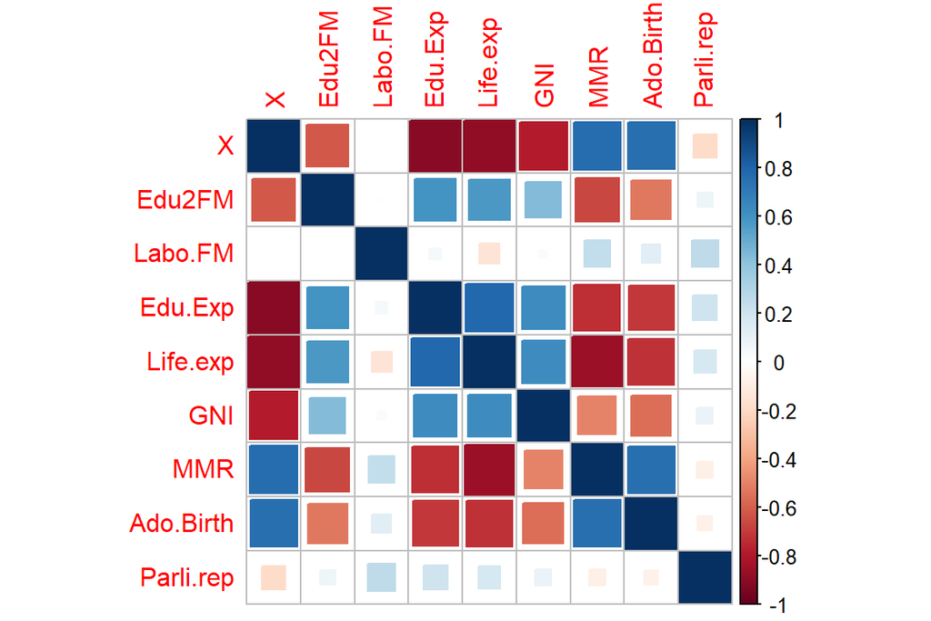

```r
cor_matrix <- cor(human_)
corrplot(cor_matrix, method = "square")
```

Note the lack of strong correlations of Representation of women in the parliament (Parli.rep) and the labour force(Labo.FM) with other variables. This will come up again in the following sections.

## Principal Component Analysis

```r
pca_unscaled <- prcomp(human_)

summary(pca_unscaled)
```

```
## Importance of components:
##                              PC1      PC2   PC3   PC4   PC5   PC6   PC7    PC8
## Standard deviation     1.854e+04 186.5901 26.22 18.72 10.95 3.137 1.078 0.1888
## Proportion of Variance 9.999e-01   0.0001  0.00  0.00  0.00 0.000 0.000 0.0000
## Cumulative Proportion  9.999e-01   1.0000  1.00  1.00  1.00 1.000 1.000 1.0000
##                           PC9
## Standard deviation     0.1591
## Proportion of Variance 0.0000
## Cumulative Proportion  1.0000
```

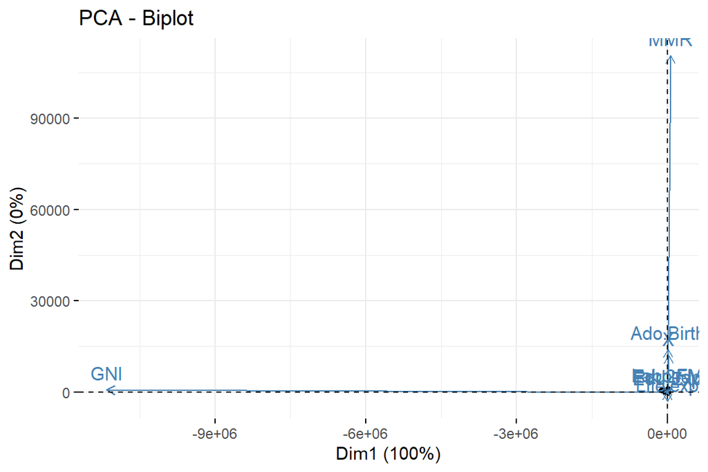

```r
fviz_pca_biplot(pca_unscaled,
                label="var", choices = 1:2)
```

Standardizing the dataset:

```r
human_std <- scale(human_)
```

Running a PCA on the scaled data:

```r
pca_scaled <- prcomp(human_std)


summary(pca_scaled)
```

```
## Importance of components:
##                           PC1    PC2     PC3     PC4     PC5    PC6     PC7
## Standard deviation     2.2770 1.1437 0.87751 0.79700 0.66196 0.5482 0.46456
## Proportion of Variance 0.5761 0.1453 0.08556 0.07058 0.04869 0.0334 0.02398
## Cumulative Proportion  0.5761 0.7214 0.80698 0.87756 0.92624 0.9596 0.98362
##                            PC8     PC9
## Standard deviation     0.32938 0.19731
## Proportion of Variance 0.01205 0.00433
## Cumulative Proportion  0.99567 1.00000
```

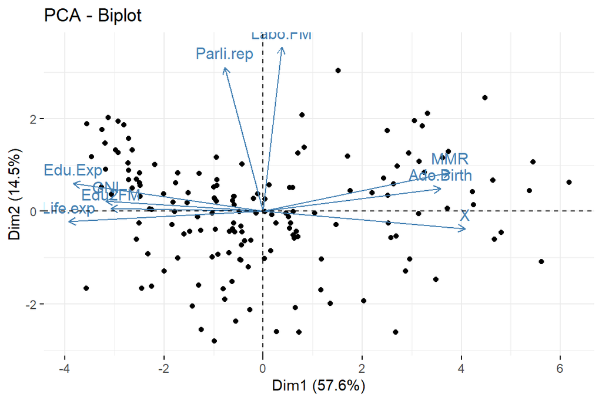

```r
fviz_pca_biplot(pca_scaled,
                label="var", choices = 1:2)
```

There are some obvious differences between the results of a PCA between the original and standardized data:

- PC1 explains 100% of the variations within the original dataset, but for the scaled dataset, PC1 explains nearly 58% of variations and PC2 explains nearly 15% of the variations.
- Maternal Mortality Ratio (MMR) and Per Capita Gross National Income (GNI) appear to be the most influential variabled in the unscaled dataset.
- In the scaled dataset, Life Expectancy, Expected years of Education, Per Capita Gross National Income, Proportion of Women with Higher Education, Proportion of women representation in the Parliament, Proportion of Women in the labour force, Maternal Mortality Ratio and Adolescent Births all make comparable comtribution to the variations.
- Taking into account the direction of the variables, the two datasets give us the following information:
  - **Unscaled dataset**: PC1 reflects the Gross National Income and PC2 reflects Maternal Mortality Ratio and Adolescent Births.
  - **Scaled dataset**: PC1 reflects indices of well-being, such as life expectancy, expected years of formal education, maternal mortality ratio, etc., while PC2 reflects the effect of these indices of well-being on servoces to the society, such as representation by women in the parliament and the labour force.
- The above observation in interesting especially in comparison to the correlation matrix, where neither women representation in the parliament or the labour force had very strong correlations with other factors. The PCA of the scaled dataset does show these variables to be directed in a different direction than most other variables.

## Multiple Correspondence Analysis

Reading the data:

```r
tea <- read.csv("https://raw.githubusercontent.com/KimmoVehkalahti/Helsinki-Open-Data-Science/master/datasets/tea.csv", stringsAsFactors = TRUE)
```

MCA:

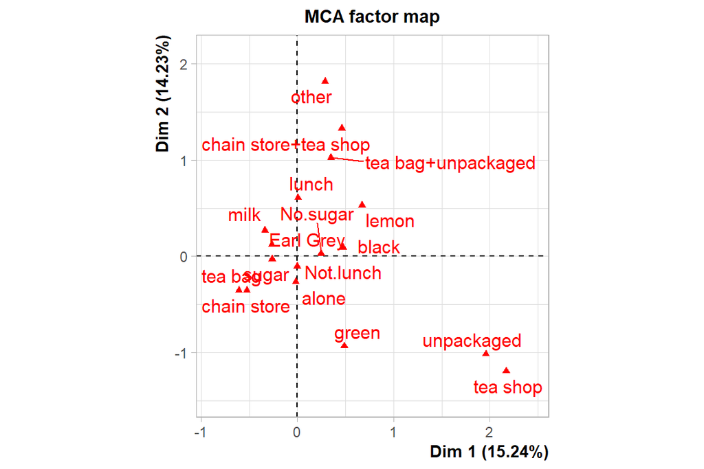

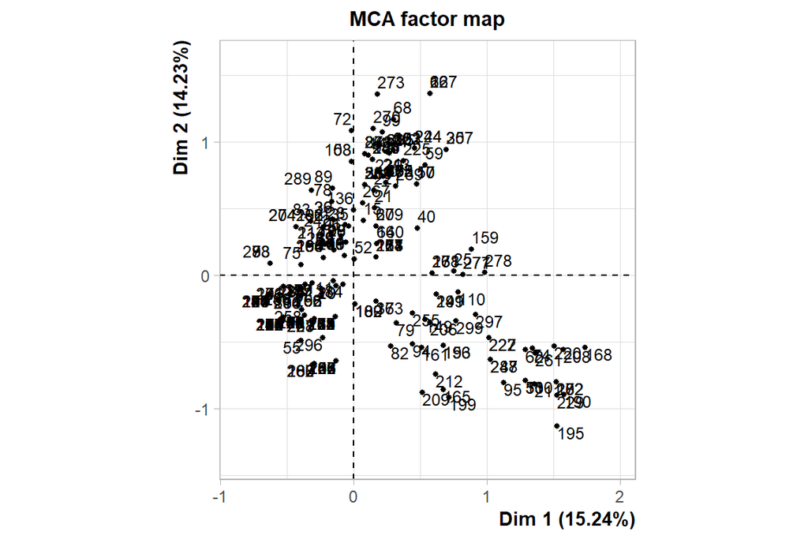

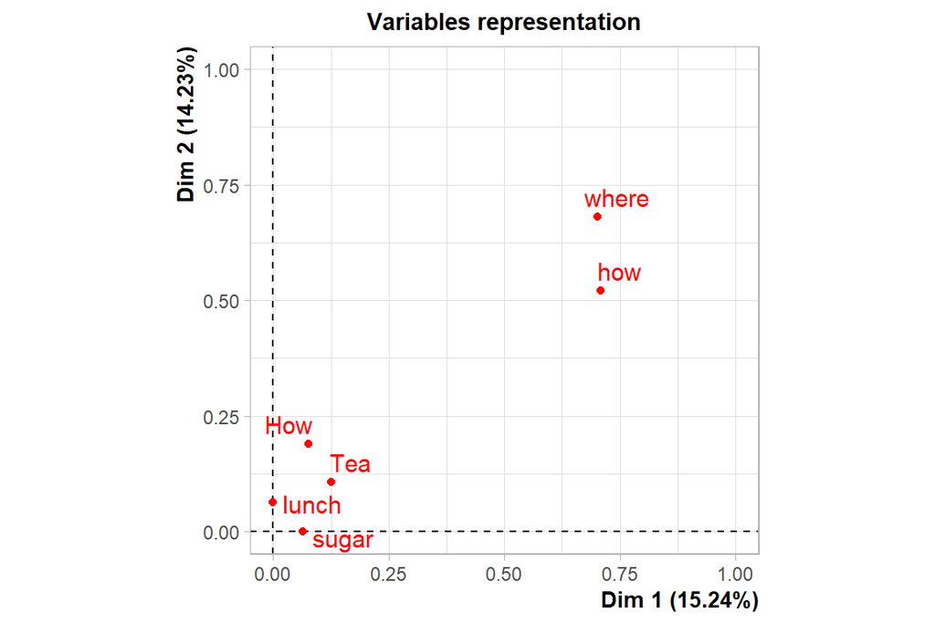

```r
# Performing an MCA on the whole dataset displayed an error so I decided to go with the columns selected in the exercise set.

keep_columns <- c("Tea", "How", "how", "sugar", "where", "lunch")
tea_time <- dplyr::select(tea, all_of(keep_columns))
mca <- MCA(tea_time, graph = TRUE)
```

```r
summary(mca)
```

```
##
## Call:
## MCA(X = tea_time, graph = TRUE)
##
##
## Eigenvalues
##                        Dim.1   Dim.2   Dim.3   Dim.4   Dim.5   Dim.6   Dim.7
## Variance               0.279   0.261   0.219   0.189   0.177   0.156   0.144
## % of var.             15.238  14.232  11.964  10.333   9.667   8.519   7.841
## Cumulative % of var.  15.238  29.471  41.435  51.768  61.434  69.953  77.794
##                        Dim.8   Dim.9  Dim.10  Dim.11
## Variance               0.141   0.117   0.087   0.062
## % of var.              7.705   6.392   4.724   3.385
## Cumulative % of var.  85.500  91.891  96.615 100.000
##
## Individuals (the 10 first)
##                       Dim.1    ctr   cos2    Dim.2    ctr   cos2    Dim.3
## 1                  | -0.298  0.106  0.086 | -0.328  0.137  0.105 | -0.327
## 2                  | -0.237  0.067  0.036 | -0.136  0.024  0.012 | -0.695
## 3                  | -0.369  0.162  0.231 | -0.300  0.115  0.153 | -0.202
## 4                  | -0.530  0.335  0.460 | -0.318  0.129  0.166 |  0.211
## 5                  | -0.369  0.162  0.231 | -0.300  0.115  0.153 | -0.202
## 6                  | -0.369  0.162  0.231 | -0.300  0.115  0.153 | -0.202
## 7                  | -0.369  0.162  0.231 | -0.300  0.115  0.153 | -0.202
## 8                  | -0.237  0.067  0.036 | -0.136  0.024  0.012 | -0.695
## 9                  |  0.143  0.024  0.012 |  0.871  0.969  0.435 | -0.067
## 10                 |  0.476  0.271  0.140 |  0.687  0.604  0.291 | -0.650
##                       ctr   cos2
## 1                   0.163  0.104 |
## 2                   0.735  0.314 |
## 3                   0.062  0.069 |
## 4                   0.068  0.073 |
## 5                   0.062  0.069 |
## 6                   0.062  0.069 |
## 7                   0.062  0.069 |
## 8                   0.735  0.314 |
## 9                   0.007  0.003 |
## 10                  0.643  0.261 |
##
## Categories (the 10 first)
```

[output cut: 16 more lines]

```
## lemon                3.226 |   1.329  14.771   0.218   8.081 |
## milk                 2.422 |   0.013   0.003   0.000   0.116 |
## other                5.534 |  -2.524  14.526   0.197  -7.676 |
## tea bag             -6.941 |  -0.065   0.183   0.006  -1.287 |
## tea bag+unpackaged  11.956 |   0.019   0.009   0.000   0.226 |
## unpackaged          -6.482 |   0.257   0.602   0.009   1.640 |
##
## Categorical variables (eta2)
##                      Dim.1 Dim.2 Dim.3
## Tea                | 0.126 0.108 0.410 |
## How                | 0.076 0.190 0.394 |
## how                | 0.708 0.522 0.010 |
## sugar              | 0.065 0.001 0.336 |
## where              | 0.702 0.681 0.055 |
## lunch              | 0.000 0.064 0.111 |
```

Plotting the MCA

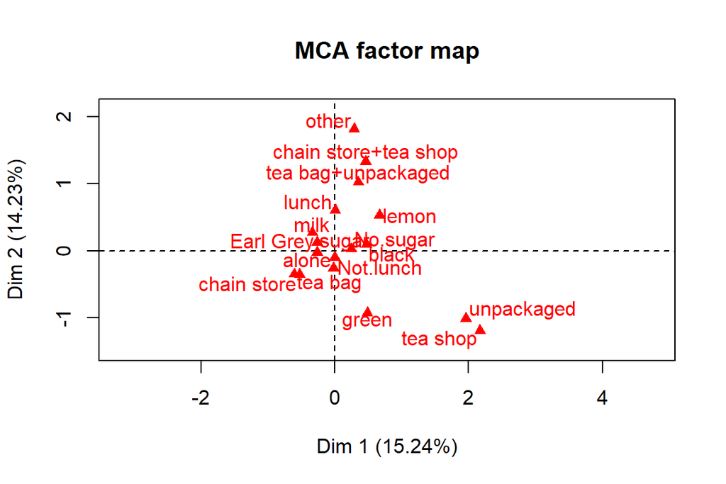

```r
plot(mca, invisible=c("ind"), graph.type = "classic")
```

The variables “unpackaged” and “tea shop” are quite separate from the rest of the variables, as are “tea bag + unpackaged”, “store + tea shop” and “others”.

# Chapter 6: Analysis of longitudinal data

Packages:

```r
options(repos = list(CRAN="http://cran.rstudio.com/"))

library(MASS)
library(corrplot)
library(readr)
library(dplyr)
library(tidyverse)
library(ggplot2)
library(GGally)
library(DT)
library(tibble)
library(tidyr)
```

Data:

```r
BPRS <- read.csv("BPRSL")
RATS <- read.csv("RATSL")
```

## The RATS dataset:

```r
DT::datatable(RATS, options = list(pageLength = 10))
```

|  | X | ID | Group | WD | Weight | Time |
| --- | --- | --- | --- | --- | --- | --- |
| 1 | 1 | 1 | 1 | WD1 | 240 | 1 |
| 2 | 2 | 2 | 1 | WD1 | 225 | 1 |
| 3 | 3 | 3 | 1 | WD1 | 245 | 1 |
| 4 | 4 | 4 | 1 | WD1 | 260 | 1 |
| 5 | 5 | 5 | 1 | WD1 | 255 | 1 |
| 6 | 6 | 6 | 1 | WD1 | 260 | 1 |
| 7 | 7 | 7 | 1 | WD1 | 275 | 1 |
| 8 | 8 | 8 | 1 | WD1 | 245 | 1 |
| 9 | 9 | 9 | 2 | WD1 | 410 | 1 |
| 10 | 10 | 10 | 2 | WD1 | 405 | 1 |

[output cut: 182 more lines]

The above data studies the temporal trends in the weight of rats, taking repeated measurements from each week, group and individual. These variables could potentially contribute to correlations between individual weights.

**Graphical Representation**

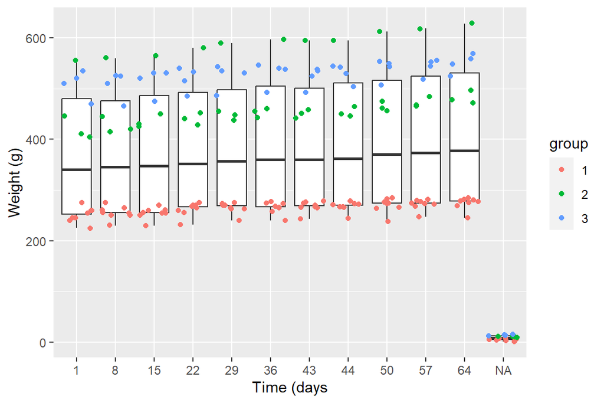

```r
RATS$timef <- factor(RATS$Time)
RATS$group <- factor(RATS$Group)
p <- ggplot(data = RATS, aes(x = timef, y = Weight)) + geom_boxplot() + geom_jitter(aes(col = group)) + xlab("Time (days") + ylab("Weight (g)")
p
```

Taking a closer look at each treatment:

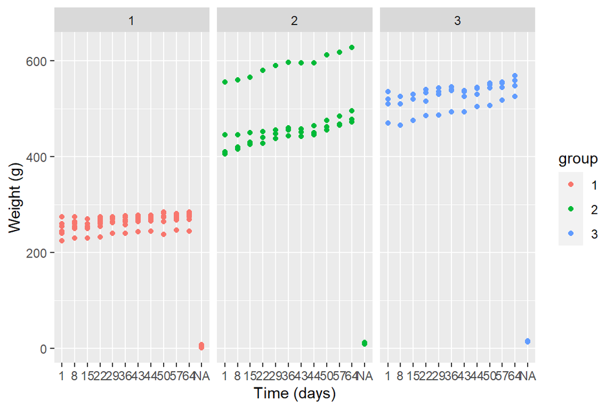

```r
p2 <- ggplot(data = RATS, aes(x = timef, y = Weight)) + geom_point(aes(col = group)) + xlab("Time (days)") + ylab("Weight (g)")

 p2 <- p2 + facet_wrap(~group)
 p2
```

There are quite some variations in Group 2. Wonder if these are contributed by the same individual. Let’s take a yet closer look at this group.

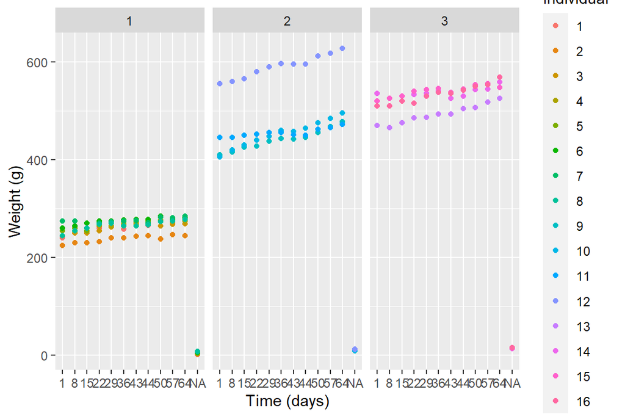

```r
RATS$individual <- factor(RATS$ID)

p3 <- ggplot(data = RATS, aes(x = timef, y = Weight)) + geom_point(aes(col = individual)) + xlab("Time (days)") + ylab("Weight (g)")

p3 <- p3 + facet_wrap(~group)
 p3
```

As suspected, the variation is contributed to by one individual, ID 12.

From the above graphs, it appears that time and group may have a significant influence on the weight of the individuals. The individuals themselves may present some variations, and these may need to be accounted for (especially ID 12).

We’ll try to see if our hypothesis is correct, using ANOVA.

```r
#let's create a summary dataset first
RATS.s <- RATS %>%
  filter(ID != 12) %>%                   #We'll remove ID 12, which is causing a lot of variation within Group 2
  group_by(Group, ID) %>%
  summarise( mean=mean(Weight) ) %>%
  ungroup()
glimpse(RATS.s)
```

```
## Rows: 15
## Columns: 3
## $ Group <int> 1, 1, 1, 1, 1, 1, 1, 1, 2, 2, 2, 3, 3, 3, 3
## $ ID    <int> 1, 2, 3, 4, 5, 6, 7, 8, 9, 10, 11, 13, 14, 15, 16
## $ mean  <dbl> 239.4167, 218.0000, 238.7500, 244.6667, 247.4167, 252.3333, 252.…
```

Let’s take a look at whether the graphical representation of the summarised data indicates any considerable differences in rat weights between groups.

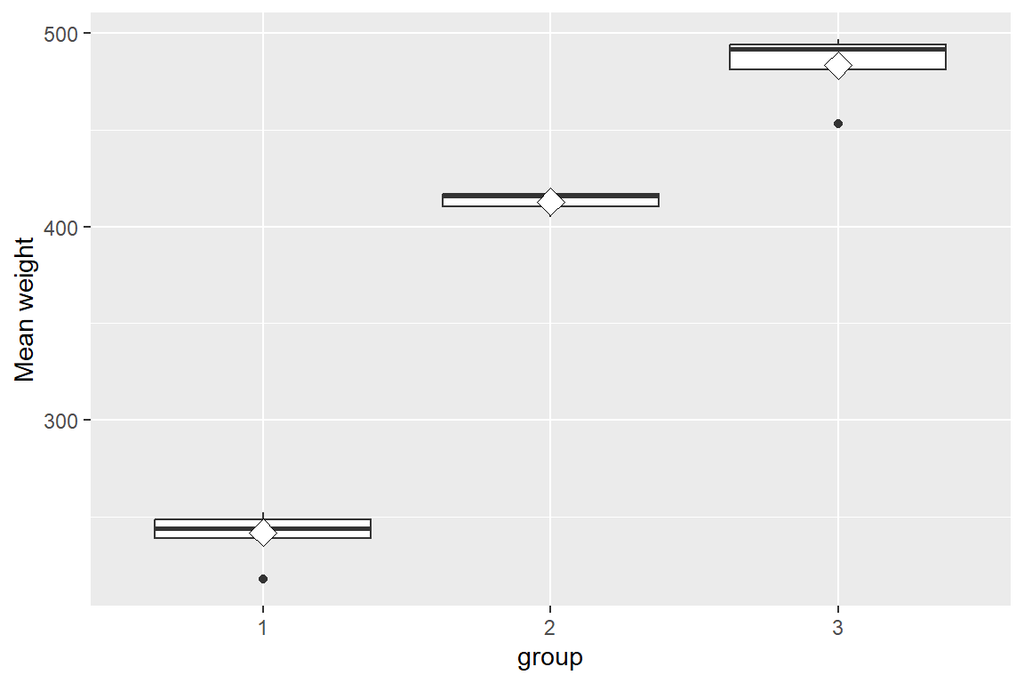

```r
RATS.s$group = factor(RATS.s$Group)
ggplot(RATS.s, aes(x = group, y = mean)) +
  geom_boxplot() +
  stat_summary(fun = "mean", geom = "point", shape=23, size=4, fill = "white") +
  scale_y_continuous(name = "Mean weight")
```

It looks like the mean weights may vary significantly between the three groups.

```r
lm_R1 <- lm(mean ~ Group + ID, data = RATS.s)
summary(lm_R1)
```

```
##
## Call:
## lm(formula = mean ~ Group + ID, data = RATS.s)
##
## Residuals:
##     Min      1Q  Median      3Q     Max
## -36.531 -11.843  -3.269   3.217  40.169
##
## Coefficients:
##             Estimate Std. Error t value Pr(>|t|)
## (Intercept)  127.622     13.979   9.130 9.49e-07 ***
## Group         98.425     18.460   5.332 0.000179 ***
## ID             5.119      3.376   1.516 0.155305
## ---
## Signif. codes:  0 '***' 0.001 '**' 0.01 '*' 0.05 '.' 0.1 ' ' 1
##
## Residual standard error: 23.77 on 12 degrees of freedom
## Multiple R-squared:  0.9616, Adjusted R-squared:  0.9552
## F-statistic: 150.4 on 2 and 12 DF,  p-value: 3.188e-09
```

```r
anova(lm_R1)
```

```
## Analysis of Variance Table
##
## Response: mean
##           Df Sum Sq Mean Sq  F value    Pr(>F)
## Group      1 168676  168676 298.5039 7.644e-10 ***
## ID         1   1299    1299   2.2995    0.1553
## Residuals 12   6781     565
## ---
## Signif. codes:  0 '***' 0.001 '**' 0.01 '*' 0.05 '.' 0.1 ' ' 1
```

It appears that the mean weights vary significantly by group (p=0), but not among individuals. (We’ll try to run the analysis with the outlier to see if that changes anything if there’s time)

## The BPRS data

```r
glimpse(BPRS)
```

```
## Rows: 360
## Columns: 6
## $ X         <int> 1, 2, 3, 4, 5, 6, 7, 8, 9, 10, 11, 12, 13, 14, 15, 16, 17, 1…
## $ treatment <int> 1, 1, 1, 1, 1, 1, 1, 1, 1, 1, 1, 1, 1, 1, 1, 1, 1, 1, 1, 1, …
## $ subject   <int> 1, 2, 3, 4, 5, 6, 7, 8, 9, 10, 11, 12, 13, 14, 15, 16, 17, 1…
## $ weeks     <chr> "week0", "week0", "week0", "week0", "week0", "week0", "week0…
## $ bprs      <int> 42, 58, 54, 55, 72, 48, 71, 30, 41, 57, 30, 55, 36, 38, 66, …
## $ week      <int> 0, 0, 0, 0, 0, 0, 0, 0, 0, 0, 0, 0, 0, 0, 0, 0, 0, 0, 0, 0, …
```

Converting variables to factors:

```r
BPRS$subject.f <- factor(BPRS$subject)
BPRS$week.f <- factor(BPRS$week)
BPRS$treatment.f <- factor(BPRS$treatment)
glimpse(BPRS)
```

```
## Rows: 360
## Columns: 9
## $ X           <int> 1, 2, 3, 4, 5, 6, 7, 8, 9, 10, 11, 12, 13, 14, 15, 16, 17,…
## $ treatment   <int> 1, 1, 1, 1, 1, 1, 1, 1, 1, 1, 1, 1, 1, 1, 1, 1, 1, 1, 1, 1…
## $ subject     <int> 1, 2, 3, 4, 5, 6, 7, 8, 9, 10, 11, 12, 13, 14, 15, 16, 17,…
## $ weeks       <chr> "week0", "week0", "week0", "week0", "week0", "week0", "wee…
## $ bprs        <int> 42, 58, 54, 55, 72, 48, 71, 30, 41, 57, 30, 55, 36, 38, 66…
## $ week        <int> 0, 0, 0, 0, 0, 0, 0, 0, 0, 0, 0, 0, 0, 0, 0, 0, 0, 0, 0, 0…
## $ subject.f   <fct> 1, 2, 3, 4, 5, 6, 7, 8, 9, 10, 11, 12, 13, 14, 15, 16, 17,…
## $ week.f      <fct> 0, 0, 0, 0, 0, 0, 0, 0, 0, 0, 0, 0, 0, 0, 0, 0, 0, 0, 0, 0…
## $ treatment.f <fct> 1, 1, 1, 1, 1, 1, 1, 1, 1, 1, 1, 1, 1, 1, 1, 1, 1, 1, 1, 1…
```

exploring the data graphically:

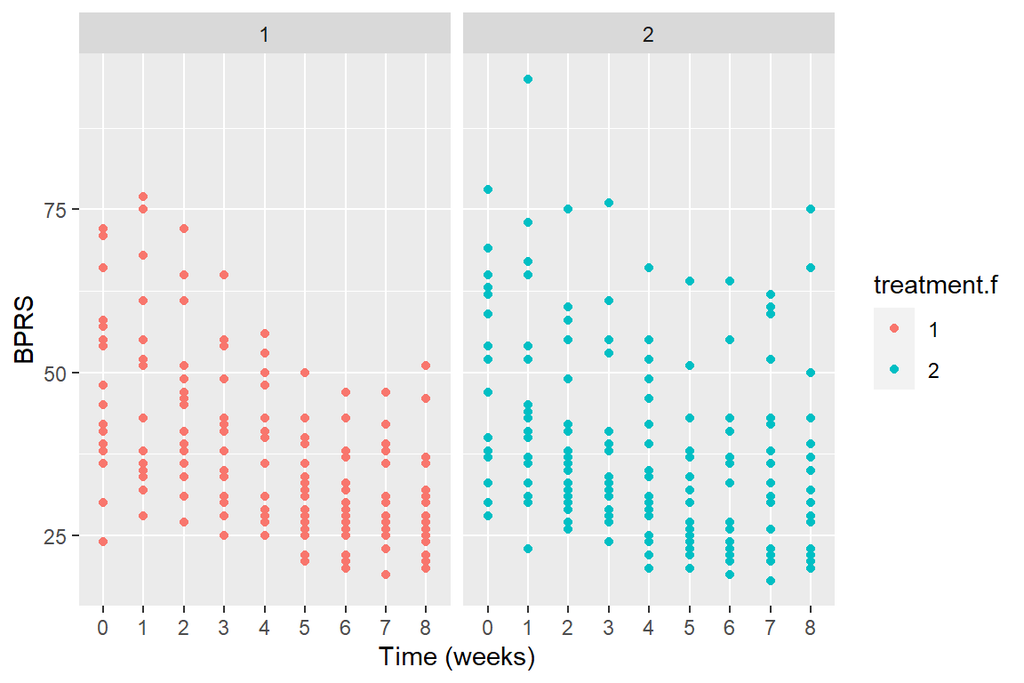

```r
library(ggplot2)
p4 <- ggplot(data = BPRS, aes(x = week.f, y = bprs)) + geom_point(aes(col = treatment.f)) + xlab("Time (weeks)") + ylab("BPRS")

p4 <- p4 + facet_wrap(~treatment.f)
 p4
```

Hmmm…. Not sure if treatment has a significant effect or not. Let’s try visualizing with a boxplot, maybe?

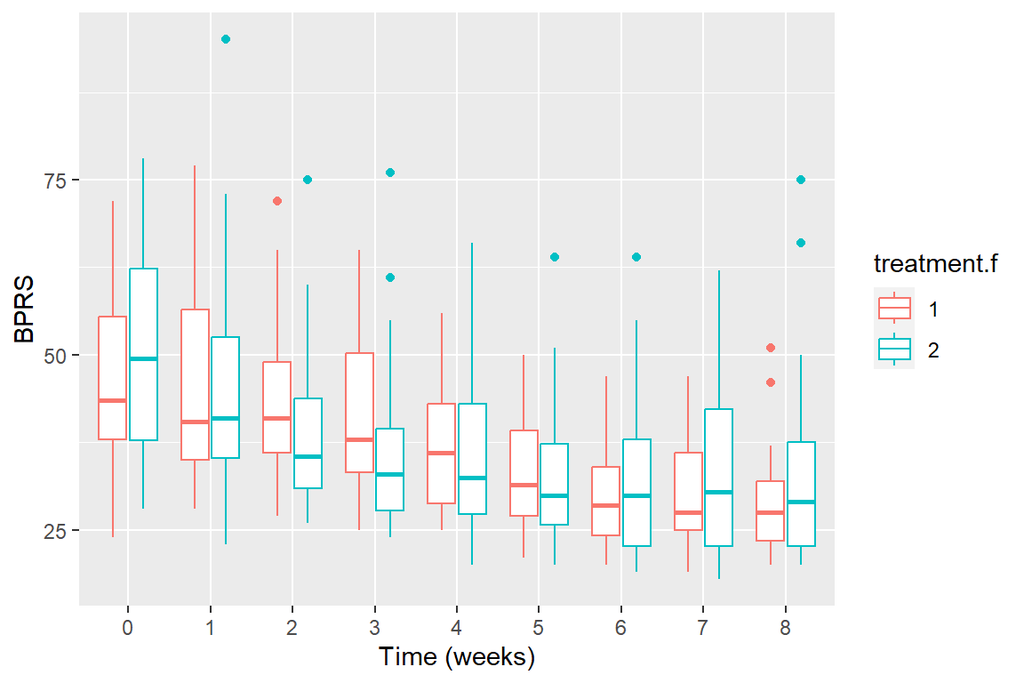

```r
p5 <- ggplot(data = BPRS, aes(x = week.f, y = bprs)) + geom_boxplot(aes(col = treatment.f)) + xlab("Time (weeks)") + ylab("BPRS")


 p5
```

The value of BPRS seems to be higher in treatment 2 in 5 out of 9 weeks. Either way, the value does decrease with each progressing week, so we may have a significant effect there.